# Supporting Information for: Phylogenetic generalised linear mixed-effects modelling with glmmTMB R package

# 1 Overview

```r
knitr::opts_chunk$set(
  warning = FALSE,
  message = FALSE
)

pacman::p_load(
  rmarkdown, readr, dplyr, purrr, splitstackshape, tidyverse, tidyr, ggplot2,
  vroom, details, sessioninfo, devtools, readxl, forcats, stringr, ape, phytools,
  geiger, data.table, pavo, MASS, glmmTMB, brms, MCMCglmm, phyr, INLA, broom.mixed,
  knitr, bayestestR, performance, rbenchmark, here, DHARMa, emmeans, purrr
)

options(digits = 4, scipen = 5)
```

This webpage provides supporting information for the manuscript “Phylogenetic generalised linear mixed-effects modelling with the glmmTMB R package”, where we showcase the [*propto*](https://cran.r-project.org/web/packages/glmmTMB/vignettes/covstruct.html#proportional) (proportional-to) covariance structure in the `glmmTMB` R package (McGillycuddy, 2023; Kristensen & McGillycuddy, 2025).

This webpage is organised in three sections:

1. First, we describe the simulated models and data-generating mechanisms for each of the five evaluated R packages for fitting PGLMMs (see Models).
2. We then use the simulated data to illustrate compilation and sampling runtimes for the Bayesian MCMC models (see Runtimes).
3. Finally, we present two case studies that apply these methods to ecological and evolutionary data, the first on bird colour traits and the second on plant traits (see Case studies).

Last updated on: 20 March 2026

# 2 Models

We demonstrate and explain how to fit phylogenetic generalized mixed models (PGLMM) using five different packages which we used in our simulation study: `glmmTMB`, `phyr`, `MCMCglmm`, `brms`, and `INLA`. The models are fitted to one simulated dataset using a randomly generated phylogenetic tree and a set of model parameters. We compare the performance of these packages in terms of runtime, accuracy, and bias of the fixed effect mean and random effect variance estimates.

We assume a set of trait measures $y_{ij}$ repeated measure (observation) $i$ and for each species $j$. The model is specified as follows:

$$y_{ij} = \beta_0 + \beta_1 x_{ij} + n_j + p_j + \varepsilon_{ij}$$

Where:

- $y_{ij}$: trait response for measure (observation) $i$ in species $j$
- $\beta_0, \beta_1$: fixed effects (intercept and slope)
- $n_i \sim \mathcal{N}(0, \sigma^2_{\text{n}})$: species-level effect (non-phylogenetic)
- $p_i \sim \mathcal{N}(0, \sigma^2_{\text{p}} \mathbf{A})$: species-level effect (phylogenetic), where $\mathbf{A}$ is the phylogenetic correlation matrix
- $\varepsilon_{ij} \sim \mathcal{N}(0, \sigma^2_{e})$: residual error

## 2.1 Simulate data

First we specify the parameter values for one simulation run. We assume the following:

```r
### set up model parameters
seed <- 123
b0 <- 1           # fixed effect intercept
b1 <- 1.5         # fixed effect slope
k.species <- 100   # number of species
n.reps <- 10      # number of repeated measures per species (assuming a balanced design)
sigma2.n <- 0.25  # variance of non-phylogenetic effect
sigma2.p <- 0.25  # variance of phylogenetic effect
sigma2.e <- 0.2   # residual error variance
```

Simulate data based on these parameter values:

```r
# set up k.obs (number of observations per species)
k.obs <- n.reps # assumes a balanced design
# species id
sp.id <- rep(seq_len(k.species), times=k.obs)
# total number of observations
n <- length(sp.id)

# simulate simple dataframe with covariate (x) variable
set.seed(seed)
x <- runif(n, 10, 20)
dat <- data.frame(obs = 1:n, x = x, species = sp.id)

# simulate tree and obtain phylo matrix
set.seed(seed)
tree <- ape::rtree(k.species, tip.label = seq_len(k.species))
tree <- ape::compute.brlen(tree, power=1) # power of 1 means ultra-metric tree
phylo.mat <- ape::vcv(tree, corr = TRUE) # we want a correlation matrix (bounded by -1 and 1) ultrametric tree
phylo.mat <- phylo.mat[order(as.numeric(rownames(phylo.mat))), order(as.numeric(rownames(phylo.mat)))]


# Simulate response variable (phen) based on cofactor and phylogenetic matrix
set.seed(seed); u.s <- rnorm(k.species, 0, sqrt(sigma2.n))[sp.id]
set.seed(seed); u.p <- MASS::mvrnorm(1, mu=rep(0, k.species), Sigma=sigma2.p*phylo.mat)[sp.id]
set.seed(seed); ei <- rnorm(n, 0, sqrt(sigma2.e))

# get estimates of y
yi <- b0 + b1*x + u.s + u.p + ei

### append all to dataframe
dat <- cbind(dat, u.s, u.p, ei, b0, b1, yi)
dat$phylo <- dat$species # phylo ID variable (same as species) - needs to be numeric to work with INLA
dat$species <- factor(dat$species) # format species variable for models
dat$sp <- dat$species # create sp variable (for phyr)
dat$g <- 1 # add variable g constant (for glmmTMB)

#
#save(dat, tree, phylo.mat, file = "simulated_data.RData")
```

View first five rows of the simulated dataset:

```r
head(dat)
```

```
  obs     x species      u.s       u.p       ei b0  b1    yi phylo sp g
1   1 12.88       1 -0.28024 -0.146108 -0.25065  1 1.5 19.64     1  1 1
2   2 17.88       2 -0.11509 -0.009422 -0.10294  1 1.5 27.60     2  2 1
3   3 14.09       3  0.77935 -0.083785  0.69708  1 1.5 23.53     3  3 1
4   4 18.83       4  0.03525  0.443331  0.03153  1 1.5 29.76     4  4 1
5   5 19.40       5  0.06464 -0.037343  0.05782  1 1.5 30.19     5  5 1
6   6 10.46       6  0.85753  0.018763  0.76700  1 1.5 18.33     6  6 1
```

## 2.2 Run models

### Run model with `glmmTMB`

To fit a PGLMM using `glmmTMB` R package we specify the species-level random effect with phylogenetic relatedness using the `propto` covariance structure (McGillycuddy, 2023; Kristensen & McGillycuddy, 2025).

The `propto(0 + species| g, phylo.mat)` covariance structure has three notable components:

1. To the left of the bar, we specify the random intercept at the species level (`0 + species`). It is very important to add `0 +` to appropriately model a multivariate species random effect. See explanations as to why this is necessary here: https://cran.r-project.org/web/packages/glmmTMB/vignettes/covstruct.html#construction-of-structured-covariance-matrices.
2. To the right of the bar, we first need to specify a factor variable, here denoted `g`, whose levels correspond to independent random‐effects vectors with shared covariance parameters. For PGLMM, it is specified as a single level for all observations (i.e. `dat$g <- 1`), so that a single random‐effect is fitted to the entire dataset.
3. After the comma on the right side of the bar, we specify the phylogenetic *correlation* matrix `phylo.mat`. We use a correlation matrix rather than a covariance matrix to avoid estimating a separate variance component per species (which would arise from each species variances). Instead, the standardized correlation matrix (with 1s on the diagonal) allows us to estimate a single phylogenetic variance component $\sigma^2_{p}$ that captures the overall magnitude of phylogenetic signal.

```r
# repeated measures per species
time.glmmTMB <- system.time({
  model_glmmTMB <- glmmTMB(yi ~ x + (1|species) + propto(0 + species|g, phylo.mat),
                           data = dat,
                           REML = TRUE)
})
```

Check if the model converged (i.e. returns `TRUE` if the Hessian is positive definite, for more details read here: https://cran.r-project.org/web/packages/glmmTMB/vignettes/troubleshooting.html):

```r
model_glmmTMB$sdr$pdHess
```

```
[1] TRUE
```

We can then get the fixed effect estimates and their confidence intervals:

```r
coefs_tmb <- as.data.frame(confint(model_glmmTMB, parm="beta_"))
coefs_tmb
```

```
             2.5 % 97.5 % Estimate
(Intercept) 0.9805  1.733    1.357
x           1.4826  1.503    1.493
```

The random effect component estimates are on the standard deviation scales from the `confint` function, so we need to square them to get the variance estimates. We also compute the standard error and confidence intervals on the variance scale using the delta method.

```r
re_tmb <- as.data.frame(confint(model_glmmTMB, parm="theta_")) # on standard deviation scale
re_tmb
```

```
                             2.5 % 97.5 % Estimate
Std.Dev.(Intercept)|species 0.4055 0.5673   0.4796
Std.Dev.species1|g          0.1278 0.7090   0.3010
```

```r
# Compute variance, SE (delta method), and CI on variance scale)
var_est <- re_tmb$Estimate^2
var_se <- 2 * re_tmb$Estimate * (re_tmb$`97.5 %` - re_tmb$`2.5 %`) / (2 * 1.96)
var_ci_low <- re_tmb$`2.5 %`^2
var_ci_high <- re_tmb$`97.5 %`^2

# Residual variance
resid_var <- sigma(model_glmmTMB)^2

# Combine results
sigma2_tmb <- data.frame(
  model = "glmmTMB",
  group = c("species", "phylo", "Residual"),
  term = "var",
  estimate = c(var_est, resid_var),
  std.error = c(var_se, NA),
  conf.low = c(var_ci_low, NA),
  conf.high = c(var_ci_high, NA))

sigma2_tmb
```

```
    model    group term estimate std.error conf.low conf.high
1 glmmTMB  species  var  0.23004   0.03959  0.16444    0.3218
2 glmmTMB    phylo  var  0.09061   0.08926  0.01633    0.5027
3 glmmTMB Residual  var  0.19904        NA       NA        NA
```

### Run model with `phyr`

To fit the model using `phyr` package we use the `cov_ranef` argument to specify the phylogenetic tree directly. The random effect term `(1|sp__)` indicates that we want to include both phylogenetic and non-phylogenetic random effects. The underscores `__` indicate that we want to include phylogenetic correlations in the model.

```r
time.phyr <- system.time({
  model_phyr <- pglmm(yi ~ x + (1|sp__),
                      cov_ranef = list(sp = tree),
                      data = dat,
                      REML = TRUE)
})
```

Obtain fixed effect estimates from model:

```r
coefs_phyr <- as.data.frame(fixef(model_phyr))
coefs_phyr$conf.low[2] <- coefs_phyr$Value[2] - coefs_phyr$Std.Error[2]*1.96
coefs_phyr$conf.high[2] <- coefs_phyr$Value[2] + coefs_phyr$Std.Error[2]*1.96
```

Obtain the random effect and residual variance estimates. Note that the phylogenetic variance estimate from `phyr` needs to be scaled by a factor to obtain the correct variance estimate.

```r
# get scaling factor for phylogenetic variance component
V <- phylo.mat
V_scaled <- V / max(V)
scale_factor <- max(V) * exp(determinant(V_scaled)$modulus[1] / nrow(V))

# get phyr random effect variance estimates
var_re_phyr <- c(as.numeric(model_phyr$s2r[2]/ scale_factor), #phylogenetic
                 as.numeric(model_phyr$s2r[1]), #non-phylogenetic
                 as.numeric(model_phyr$s2resid)) #residual


# combine into dataframe
sigma2_phyr <- data.frame(
  model = "phyr",
  group = c("phylo", "species", "Residual"),
  term = "var",
  estimate = var_re_phyr,
  std.error = NA,
  conf.low = NA,
  conf.high = NA
)

sigma2_phyr
```

```
  model    group term estimate std.error conf.low conf.high
1  phyr    phylo  var   1.3350        NA       NA        NA
2  phyr  species  var   0.1316        NA       NA        NA
3  phyr Residual  var   0.2060        NA       NA        NA
```

### Run model with `MCMCglmm`

To fit the MCMCglmm model we first we need to set up a precision matrix for the phylogenetic random effect, which (which is the inverse of the phylogenetic covariance matrix). We use the `inverseA` function the package to obtain the inverse of the phylogenetic covariance matrix.

These priors specify weakly informative settings: both random effects ($G1$, $G2$) use inverse-Wishart style priors ($V=1$, $\nu=1$, with $\alpha.\mu=0$, $\alpha.V=1000$), while the residual variance ($R$) has an almost flat inverse-Gamma prior ($V=1$, $\nu=0.02$).

```r
# get precision phylo matrix and order rows
phylo.prec.mat <- MCMCglmm::inverseA(tree)$Ainv

# set priors for two random effects
prior <- list(G=list(G1=list(V=1,nu=1,alpha.mu=0,alpha.V=1000),
                     G2=list(V=1,nu=1,alpha.mu=0,alpha.V=1000)),
              R=list(V=1,nu=0.02))

# fit MCMCglmm model
time.mcmc <- system.time({
  model_mcmc <- MCMCglmm(yi ~ x,
                         random = ~species + phylo,
                         family = "gaussian",
                         ginverse = list(phylo = phylo.prec.mat),
                         prior = prior,
                         data = dat,
                         verbose = FALSE,
                         nitt = 103000, # increase default by x10
                         burnin = 3000, # default
                         thin = 1)
})
```

Plot the trace plots of the parameters to check for convergence. We expect to see good mixing of the chains and no trends.

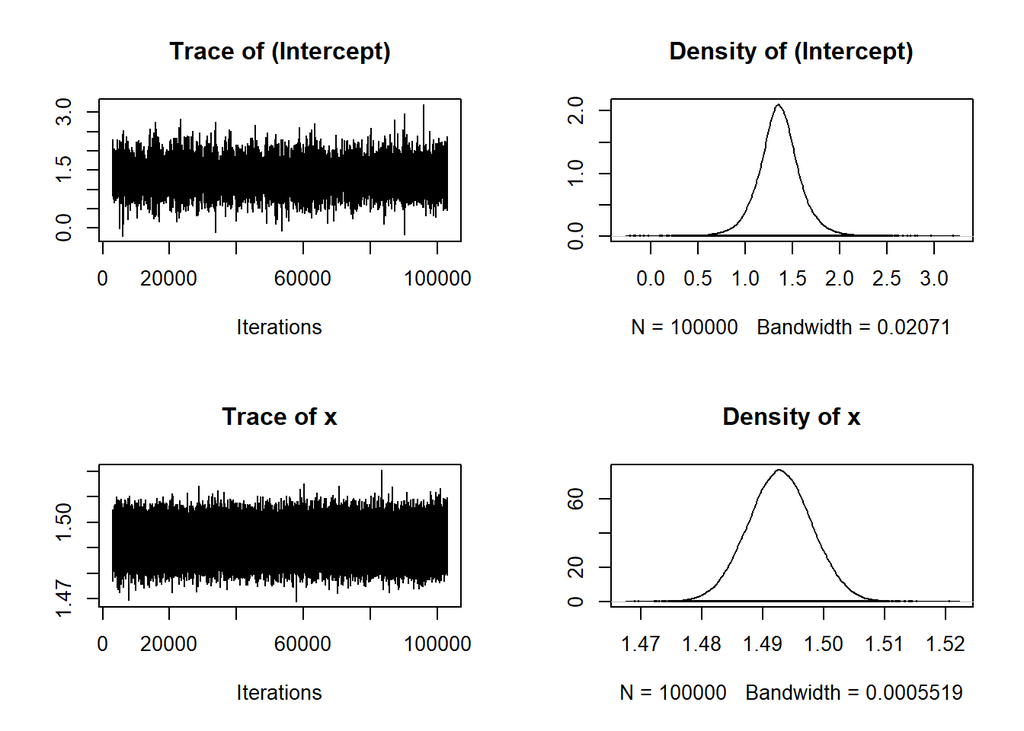

```r
plot(model_mcmc$Sol, ask = FALSE)
```

Next we check the effective sample size (ESS). The ESS should be above 400 for both fixed and random effects and the Rhat value should be below 1.01 (Vehtari et al., 2021).

```r
min(effective_sample(model_mcmc, effects = "fixed")$ESS)
```

```
[1] 100000
```

```r
min(effective_sample(model_mcmc, effects = "random")$ESS)
```

```
[1] 1585
```

We can also check the Heidelberger diagnostic test which checks if the MCMC chains have converged and are stationary ( we expect to see ‘passed’ for all parameters). In practice it is important to inspect diagnostic plots of the Markov chains and posterior distributions.

```r
fullchain <- cbind(as.mcmc(model_mcmc$Sol), as.mcmc(model_mcmc$VCV))
heidel.diag(fullchain)
```

```
            Stationarity start     p-value
            test         iteration
(Intercept) passed           1     0.132
x           passed       30001     0.113
species     passed           1     0.406
phylo       passed           1     0.944
units       passed           1     0.718

            Halfwidth Mean  Halfwidth
            test
(Intercept) passed    1.358 0.0014076
x           passed    1.493 0.0000386
species     passed    0.239 0.0009830
phylo       passed    0.137 0.0063496
units       passed    0.199 0.0000647
```

Obtain the fixed effect estimates with the `tidy` function:

```r
coefs_mcmc <- as.data.frame(tidy(model_mcmc, effects="fixed", conf.int=TRUE))
coefs_mcmc
```

```
  effect        term estimate std.error conf.low conf.high
1  fixed (Intercept)    1.358  0.227103   0.9011     1.824
2  fixed           x    1.493  0.005207   1.4826     1.503
```

Obtain the random effect and residual variance estimates:

```r
# get MCMCglmm random effect estimates (variance scale)
sigma2_mcmc <- tidy(model_mcmc, effects="ran_pars", conf.int=TRUE)
sigma2_mcmc <- sigma2_mcmc %>%
  mutate(model="MCMCglmm",
         group=str_replace(group,"animal", "phylo")) %>%
  dplyr::select(model, group, term, estimate, std.error, conf.low, conf.high)

sigma2_mcmc
```

```
# A tibble: 3 × 7
  model    group    term             estimate std.error conf.low conf.high
  <chr>    <chr>    <chr>               <dbl>     <dbl>    <dbl>     <dbl>
1 MCMCglmm species  var__(Intercept)    0.239   0.0430   0.167       0.334
2 MCMCglmm phylo    var__(Intercept)    0.137   0.129    0.00292     0.476
3 MCMCglmm Residual var__Observation    0.199   0.00944  0.182       0.219
```

### Run model with `brms`

To fit the model using the `brms` package we specify the random effects using the `(1|species)` term for non-phylogenetic random effects and `gr(phylo, cov = phylo.mat)` for phylogenetic random effects. The `data2` argument is used to pass the phylogenetic correlation matrix to the model (the same matrix format as for glmmTMB). We set the number of iterations, chains, and cores to reasonable values to ensure convergence and stability of the MCMC chains. Here we increased the number of iterations by 10 times the default value to ensure convergence and stability of the MCMC chains, but this could be further increased (and should be if ESS are low and Rhat values are higher than 1.01).

```r
time.brms <- system.time({
  model_brms <- brm(yi ~ x + (1|species) + (1|gr(phylo, cov = phylo.mat)), #phylo.mat is the correlation matrix
                    data = dat,
                    family = gaussian(),
                    chains = 4, # default
                    iter = 20000, # increased default x10
                    cores = 4, # equal to number of chains
                    data2 = list(phylo.mat = phylo.mat))
})
```

Look at the trace plots of the parameters to check for convergence. We expect to see good mixing of the chains and no trends.

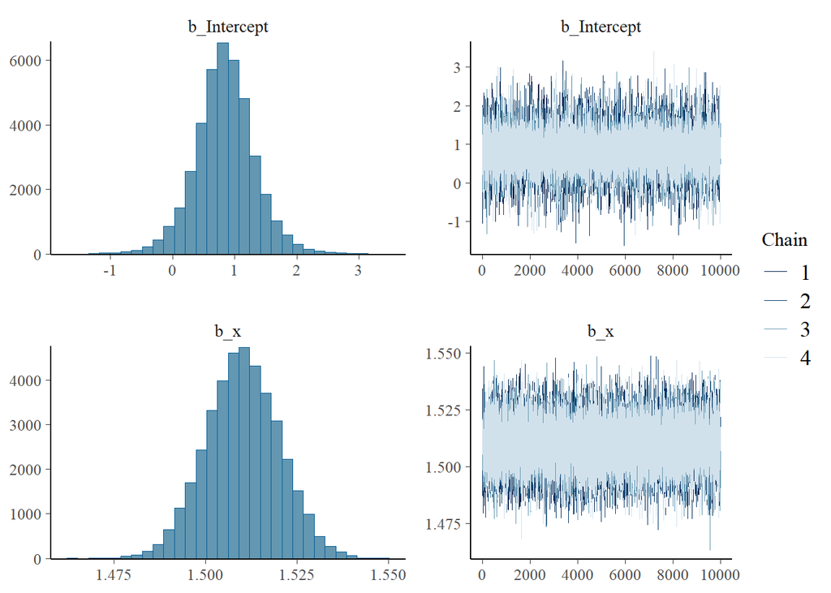

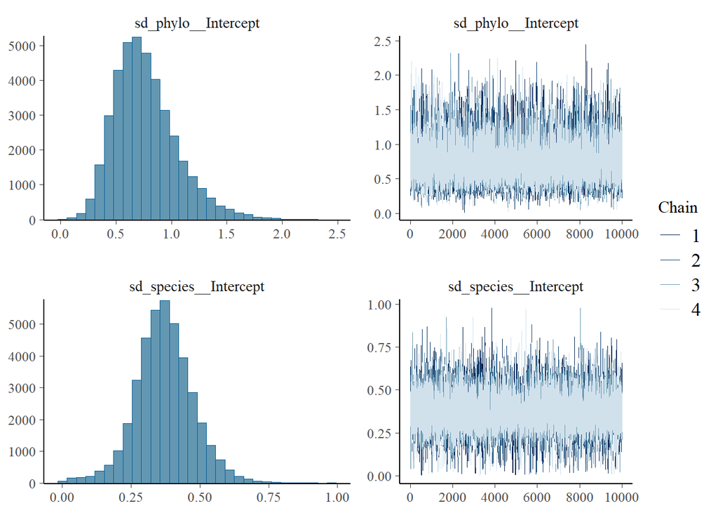

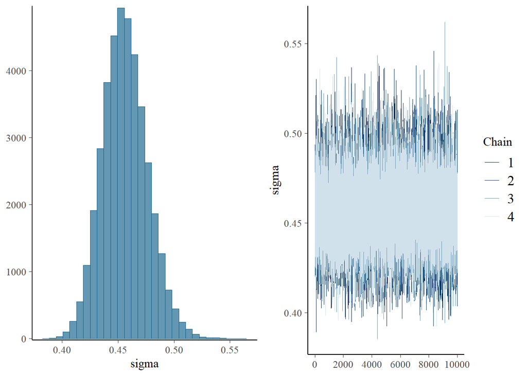

```r
plot(model_brms, N = 2, ask = FALSE)
```

```r
# check ESS
min(bayestestR::effective_sample(model_brms, effects = "fixed")$ESS)
```

```
[1] 30407
```

```r
min(bayestestR::effective_sample(model_brms, effects = "random")$ESS)
```

```
[1] 9674
```

```r
# check RHat value is below 1.01 (Vehtari et al. 2021)
max(rhat(model_brms))<1.01
```

```
[1] TRUE
```

```r
# alternatively, we can use the bayestestR package to check the diagnostics of fixed effects
print(bayestestR::diagnostic_posterior(model_brms), digits = 4)
```

```
    Parameter   Rhat   ESS       MCSE
1 b_Intercept 1.0000 29180 0.00273404
2         b_x 0.9999 95469 0.00003248
```

We can also use the diagnostic test from the `bayestestR` package to check the convergence of the MCMC chains.

```r
print(bayestestR::diagnostic_posterior(model_brms),
digits = 4)
```

```
    Parameter   Rhat   ESS       MCSE
1 b_Intercept 1.0000 29180 0.00273404
2         b_x 0.9999 95469 0.00003248
```

Obtain the fixed effect estimates with `tidy` function:

```r
coefs_brm <- as.data.frame(tidy(model_brms, effects="fixed", conf.int=TRUE))
coefs_brm
```

```
  effect component        term estimate std.error conf.low conf.high
1  fixed      cond (Intercept)   0.8433   0.47675  -0.1189     1.811
2  fixed      cond           x   1.5101   0.01003   1.4905     1.530
```

Obtain the random effect and residual variance estimates:

```r
sigma_brms <- tidy(model_brms, effects="ran_pars")
sigma2_brms <- sigma_brms %>%
  mutate(model="brms",
         term=str_replace(term, "sd", "var"),
         estimate=estimate^2) %>%     ##compute variance estimates
  dplyr::select(model, group, term, estimate, std.error, conf.low, conf.high)

sigma_brms
```

```
# A tibble: 3 × 8
  effect   component group    term         estimate std.error conf.low conf.high
  <chr>    <chr>     <chr>    <chr>           <dbl>     <dbl>    <dbl>     <dbl>
1 ran_pars cond      phylo    sd__(Interc…    0.768    0.285     0.323     1.44
2 ran_pars cond      species  sd__(Interc…    0.371    0.106     0.154     0.586
3 ran_pars cond      Residual sd__Observa…    0.456    0.0200    0.419     0.497
```

### Run model with `INLA`

For the `INLA` package we set up the model using the `f()` function to specify the random effects. The `model = "iid"` argument indicates that we want to use an independent and identically distributed (iid) random effect for species, while the `model = "generic0"` argument is used for the phylogenetic random effect. The `Cmatrix` argument is used to specify the phylogenetic correlation matrix, which should be a precision matrix similar to `MCMCglmm`. We note that priors can be incorporated for parameter using the argument `hyper=`.

```r
time.inla <- system.time({
  model_inla <- inla(yi ~ x + f(species, model = "iid") +
                       f(phylo, ## this needs to be a numeric to work
                         model = "generic0",
                         Cmatrix = phylo.prec.mat),
                     family = "gaussian",
                     data = dat)
})

fit_inla <- summary(model_inla)
```

Obtain the fixed effect estimates:

```r
coefs_inla <- as.data.frame(fit_inla$fixed)
coefs_inla
```

```
             mean   sd 0.025quant 0.5quant 0.975quant mode kld
(Intercept) 0.841 0.38      0.073     0.84      1.613 0.84   0
x           1.510 0.01      1.491     1.51      1.530 1.51   0
```

Obtain the random effect variance estimates. Note that `INLA` provides the **inverse of the variance** (precision) in their output.

```r
re_inla <- 1/fit_inla$hyperpar
sigma2_inla <- data.frame(
  model = "INLA",
  group = c( "Residual", "species", "phylo"),
  term = "var",
  estimate = re_inla$mean,
  std.error = fit_inla$hyperpar$sd,
  conf.low = re_inla$`0.025quant`,
  conf.high = re_inla$`0.975quant`
)

sigma2_inla
```

```
  model    group term estimate std.error conf.low conf.high
1  INLA Residual  var   0.2045     0.421   0.2435   0.17358
2  INLA  species  var   0.1177     4.134   0.3388   0.05315
3  INLA    phylo  var   0.1999     4.717   1.1547   0.05707
```

**Additional note:** if a model returns extreme or unreasonable variance estimates, it is important to check robustness by refitting the same model with another package. In INLA, centering the random effect estimates (by specifying `const = TRUE` within the random effect term) or trying higher starting values (default is 4, e.g. `hyper = list(prec=list(initial=8))`) to see if the estimates converge to more reasonable values. Random effect variance estimates are often unstable, so they should be interpreted with care.

### Model estimates

Summary of model runtime, covariate $x$ estimate and it’s confidence interval for each model:

```r
time.phyr <- as.numeric(time.phyr[3])
time.glmmTMB <- as.numeric(time.glmmTMB[3])
time.brms <- as.numeric(time.brms[3])
time.mcmc <- as.numeric(time.mcmc[3])
time.inla <- as.numeric(time.inla[3])


# combine fixed effect results
res_fixed <- data.frame(
  model = c("phyr", "glmmTMB", "brms", "MCMCglmm", "INLA"),
  species_size = k.species,
  sample_size = n,
  run_time = c(time.phyr, time.glmmTMB, time.brms, time.mcmc, time.inla),
  b0 = rep(dat$b0[1], 5),
  b1 = rep(dat$b1[1], 5),
  mu = c(coefs_phyr$Value[2],
         coefs_tmb$Estimate[2],
         coefs_brm$estimate[2],
         coefs_mcmc$estimate[2],
         coefs_inla$mean[2]),
  mu_ci_low = c(coefs_phyr$conf.low[2],
                coefs_tmb$`2.5 %`[2],
                coefs_brm$conf.low[2],
                coefs_mcmc$conf.low[2],
                coefs_inla$`0.025quant`[2]),
  mu_ci_high = c(coefs_phyr$conf.high[2],
                 coefs_tmb$`97.5 %`[2],
                 coefs_brm$conf.high[2],
                 coefs_mcmc$conf.high[2],
                 coefs_inla$`0.975quant`[2]),
  stringsAsFactors = FALSE
)

kable(res_fixed,
  caption = "Runtime and fixed effect estimates of the simulated model",
  col.names = c("Model", "Species size", "Sample size", "Run time (s)", "b0", "b1", "Estimate (b1)", "CI low (b1)", "CI high (b1)"),
  digits = 3,
  format = "html"
)
```

Runtime and fixed effect estimates of the simulated model

[output not shown]

Summary of variance component estimates for each model:

```r
# combine results together
s2 <- as.data.frame(rbind(sigma2_phyr,
                          sigma2_tmb,
                          sigma2_brms,
                          sigma2_mcmc,
                          sigma2_inla))

# get subsets for each group
s2_phylo <- s2 %>% filter(group=="phylo")
s2_sp <- s2 %>% filter(group=="species")
s2_res <- s2 %>% filter(group=="Residual")


res_rand <- data.frame(
  model = c("phyr", "glmmTMB", "brms", "MCMCglmm", "INLA"),
  species_size = k.species,
  sample_size = n,
  run_time = c(time.phyr, time.glmmTMB, time.brms, time.mcmc, time.inla),
  sigma2_phylo = s2_phylo$estimate,
  sigma2_species = s2_sp$estimate,
  sigma2_residual = s2_res$estimate,
  stringsAsFactors = FALSE
)

kable(res_rand,
  caption = "Runtime and random component variance estimates of the simulated model",
  col.names = c("Model", "Species size", "Sample size", "Run time (s)", "Phylo variance est.", "Non-phylo variance est.", "Residual variance est."),
  digits = 3,
  format = "html"
)
```

Runtime and random component variance estimates of the simulated model

[output not shown]

## 2.3 Extra analyses and notes

**One measure per species**

> Sometimes we only have one measure per species. This may happen because of limited sampling or because repeated observations for a species have already been averaged. In such cases, it is common to work with a single value per species.

```r
dat.m <- dat |>
  group_by(species) |>
  summarise(
    x_mean   = mean(x, na.rm = TRUE),
    u.s_mean = mean(u.s, na.rm = TRUE),
    u.p_mean = mean(u.p, na.rm = TRUE),
    ei_mean  = mean(ei, na.rm = TRUE),
    yi_mean  = mean(yi, na.rm = TRUE),
    g = 1,
    .groups = "drop"
  )

head(dat.m)
```

```
# A tibble: 6 × 7
  species x_mean u.s_mean u.p_mean ei_mean yi_mean     g
  <fct>    <dbl>    <dbl>    <dbl>   <dbl>   <dbl> <dbl>
1 1         15.7  -0.280  -0.146   -0.0347    24.1     1
2 2         14.5  -0.115  -0.00942 -0.205     22.3     1
3 3         14.7   0.779  -0.0838   0.0415    23.8     1
4 4         15.5   0.0353  0.443    0.0595    24.9     1
5 5         14.7   0.0646 -0.0373  -0.0772    22.9     1
6 6         15.8   0.858   0.0188  -0.0144    25.6     1
```

As there is only one observation per species, we cannot fit a non-phylogenetic effect, as it won’t be separately identifiable from the phylogenetic effect. Therefore, we only include the phylogenetic random effect in the model (see Equation 3 in the manuscript). The model is specified as follows:

```r
m <- glmmTMB(
  yi_mean ~ x_mean + propto(0 + species|g, phylo.mat),
  data = dat.m,
  REML = TRUE
)

# > summary(m)
#  Family: gaussian  ( identity )
# Formula:          yi_mean ~ x_mean + propto(0 + species | g, phylo.mat)
# Data: dat.m
#
#       AIC       BIC    logLik -2*log(L)  df.resid
#     171.0     181.4     -81.5     163.0        96
#
# Random effects:
#
# Conditional model:
#  Groups   Name      Variance Std.Dev. Corr
#  g        species1  0.0855   0.292
#           species2  0.0855   0.292    0.87
#           species3  0.0855   0.292    0.87 0.96
#           species4  0.0855   0.292    0.00 0.00 0.00
#           species5  0.0855   0.292    0.67 0.67 0.67 0.00
#           species6  0.0855   0.292    0.00 0.00 0.00 0.70 0.00
#           species7  0.0855   0.292    0.47 0.47 0.47 0.00 0.47 0.00
#           species8  0.0855   0.292    0.31 0.31 0.31 0.00 0.31 0.00 0.31
#           species9  0.0855   0.292    0.80 0.80 0.80 0.00 0.67 0.00 0.47 0.31
#           species10 0.0855   0.292    0.31 0.31 0.31 0.00 0.31 0.00 0.31 0.97 0.31
#           ...       ...      ...      ...  ...  ...  ...  ...  ...  ...  ...  ...  ...
#  Residual           0.2528   0.503
# Number of obs: 100, groups:  g, 1
#
# Dispersion estimate for gaussian family (sigma^2): 0.253
#
# Conditional model:
#             Estimate Std. Error z value Pr(>|z|)
# (Intercept)   1.8540     0.8537    2.17     0.03 *
# x_mean        1.4596     0.0558   26.14   <2e-16 ***
# ---
# Signif. codes:  0 ‘***’ 0.001 ‘**’ 0.01 ‘*’ 0.05 ‘.’ 0.1 ‘ ’ 1


# fixed effect estimates
as.data.frame(confint(m, parm="beta_"))
```

```
             2.5 % 97.5 % Estimate
(Intercept) 0.1807  3.527    1.854
x_mean      1.3501  1.569    1.460
```

```r
# random component estimates (on SD scale)
as.data.frame(confint(m, parm="theta_"))
```

```
                    2.5 % 97.5 % Estimate
Std.Dev.species1|g 0.1204 0.7104   0.2925
```

```r
# residual variance estimate
sigma(m)^2
```

```
[1] 0.2528
```

There is evidence of a positive association between `x` and the response, with an estimated effect of 1.46 (95% CI: 1.35–1.57). The phylogenetic variance component estimate is 0.08 and the residual variance estimate is 0.25. Hence the proportion of total variance explained by evolutionary relationships (i.e. phylogenetic signal) is $0.0855/(0.2528+0.0855) = 0.25$.

**Random slope**

> In some analyses, we may want to include a random slope for the phylogenetic effect. This allows us to ask whether the relationship between a covariate and the response varies among species in a way that reflects their shared evolutionary history. For example, we might be interested in whether species with different body weights show different slopes in a phylogenetically structured way.

**Note**

**Important note:** fitting a random slope with the `propto` implementation is currently only supported for continuous variables, not yet for categorical variables.

Given the above simulated dataset, we assume a set of trait measures $y_{ij}$ repeated measure (observation) $i$ and for each species $j$. The phylogenetic random slope model assuming independence is specified as follows:

$$y_{ij} = \beta_0 + \beta_1 x_{ij} + n_j + p_{0j} + p_{1j}\,x_{ij} + \varepsilon_{ij}$$

Where:

- $p_{0} \sim \mathcal{N}(0, \sigma^2_{p0}\mathbf{A})$: phylogenetic random intercept
- $p_{1} \sim \mathcal{N}(0, \sigma^2_{p1}\mathbf{A})$: phylogenetic random slope, independent of $p_{0}$

```r
m.slope <- glmmTMB(yi ~ x +
                     (1|species) +
                     propto(0 + species|g, phylo.mat) +
                     propto(0 + x:species|g, phylo.mat),
                   data = dat,
                   REML = TRUE)
```

Then we can obtain the variance estimates:

```r
vc.slope <- VarCorr(m.slope)
vc.slope$cond$species[1] #non-phylo variance
```

```
[1] 0.23
```

```r
vc.slope$cond$g[1] #phylo intercept variance
```

```
[1] 0.09061
```

```r
vc.slope$cond$g.1[1] #phylo slope variance
```

```
[1] 1.076e-11
```

**Note**

**Important note:** currently the order matters when fitting a random slope with `propto`. The covariate for the random slope (here it is `x`) needs to be put first before the `species` factor variable. If we were to try `propto(0 + species:x|g, phylo.mat)` this would return an error.

### What if there is a correlation between random intercept and slope?

`glmmTMB` cannot currently estimate correlated random intercepts and slopes when using the `propto` covariance structure. This means the intercept–slope covariance is fixed at zero and cannot be separated out. A common workaround is to **centre the covariate**, which reparameterises the model so that the intercept represents the expected response at the mean covariate value. This improves interpretability and typically stabilises slope variance estimates, though it does not recover any true intercept–slope correlation.

When the data contain little or no correlation, variance estimates from `glmmTMB` with centred covariates are generally similar to those from packages that estimate the correlation. However, when the correlation is strong, `glmmTMB` may distort the partitioning of variance because the shared variation has no explicit covariance term.

For comparison, the random-effects structure in a model with correlated random intercepts and slopes is:

$$\begin{bmatrix}
\sigma^2_{\text{intercept}} & \sigma_{\text{intercept},\text{slope}} \\
\sigma_{\text{intercept},\text{slope}} & \sigma^2_{\text{slope}}
\end{bmatrix}$$

while in `glmmTMB` with `propto` it is constrained to:

$$\begin{bmatrix}
\sigma^2_{\text{intercept}} & 0 \\
0 & \sigma^2_{\text{slope}}
\end{bmatrix}$$

**Recommendation:** fit models in both `glmmTMB` and in Bayesian frameworks such as the `brms` and `MCMCglmm` packages in R. Use globally centred covariates in both cases: centring helps stabilise estimation in `glmmTMB` and also improves interpretability in Bayesian models, though Bayesian approaches can additionally estimate the correlation directly.

- If there is **truly little or no correlation**, the results will look very similar to `glmmTMB`: the variance estimates will be close, and the correlation will be near zero.
- If there is **strong correlation**, the slope and intercept variance estimates in `glmmTMB` may still approximate the overall variability, but they could be biased, because part of the shared variation is forced into the variance components rather than partitioned as covariance.

**Phylogenetic tree uncertainty**

> Phylogenetic trees are always approximations and never represent the “true” evolutionary history with complete accuracy. In some cases, however, we may have access to multiple candidate trees. These can be used to fit separate models and then combine the results, for example using Rubin’s rules (Rubin, 1987), treating trees like imputations of the unknown phylogeny.

Here, we illustrate how to incorporate tree uncertainty with the simulated repeated-measures dataset. Using about 50 trees is often sufficient for high relative efficiency of the pooled estimates i.e., little further gain (Nakagawa & de Villemereuil, 2019).

As a first step, we generate 50 random phylogenetic trees to represent a set of hypothetical candidate trees. In practice, candidate trees can be obtained from different posterior distributions of phylogenetic trees using Bayesian inference of phylogenies.

```r
set.seed(123)

# 'k.species' and 'dat' are obtained from the 'Simulate data' section
# where dat$species is set as a factor => make sure to run this first.

# simulate 50 random trees
trees <- replicate(50, ape::rtree(k.species, tip.label = seq_len(k.species)), simplify = FALSE)

# now make a phylogenetic correlation matrix for each tree,
make_phylo_mat <- function(tree, sp) {
  C <- vcv(tree, corr = TRUE)
  C <- C[order(as.numeric(rownames(C))), order(as.numeric(rownames(C)))]
}

p.mats <- lapply(trees, make_phylo_mat, sp = sp.id)
```

**Note**

**Important note:** the row `rownames(C)` and column names `colnames(C)` of the phylogenetic correlation matrix must match `levels(dat$species)`, in the same order to be able to fit with `glmmTMB`.

We fit the same model across 50 candidate trees:

```r
# function to fit PGLMM with different tree
fit_model <- function(Pmat) {
  glmmTMB(yi ~ x + (1|species) + propto(0 + species|g, Pmat),
                 data = dat, REML = TRUE)
}

# fit PGLMM model across all phylo correlation matrices
fits <- purrr::map(p.mats, fit_model)
```

Then using two packages `mice` and `mitml` we pool model estimates using Rubin’s rules.

First we get the pooled `mice` fixed effect estimates:

```r
### with mice package
library(mice)
summary(mice::pool(fits))
```

```
         term estimate std.error statistic    df   p.value
1 (Intercept)    1.351  0.106878     12.64 945.2 5.842e-34
2           x    1.493  0.005178    288.27 993.0 0.000e+00
```

By default, `mice::pool` uses the **Barnard–Rubin small-sample adjustment** (Barnard and Rubin, 1999) for degrees of freedom (df), which shrinks the `df` towards the complete-data df. Consequently, confidence intervals are slightly wider and p-values a little larger than under Rubin’s original (“old”) rule.

Now we get the pooled `mitml` fixed effect estimates:

```r
### with miml package
library(mitml)
fit.est <- mitml::testEstimates(fits, extra.pars=TRUE)
head(fit.est$estimates)
```

```
            Estimate Std.Error t.value          df P(>|t|)        RIV
(Intercept)    1.351  0.106878   12.64       52318       0 0.03156979
x              1.493  0.005178  288.27 15959151919       0 0.00005541
                   FMI
(Intercept) 0.03064070
x           0.00005541
```

We obtain the same fixed effect estimates in both packages. However, `mitml` by default uses Rubin’s original degrees of freedom (“old rule”). This may be suitable if you deliberately want z-like inference.

If you wish to use `mitml` and obtain the fixed effect estimates inference using the Barnard–Rubin small-sample adjustment for degrees of freedom, you can obtain use the residual degrees of freedom from the models as a proxy for the complete-data df:

$$df.com \approx N−p$$

where $N$ is the number of observations used and $p$ is the number of conditional fixed-effect coefficients. Because we are fitting the same model across different phylogenetic matrices, `df.com` will be the same for all fits.

```r
# residual degrees of freedom of models
df.res <- vapply(fits, df.residual, numeric(1))
df.com <- unique(df.res) ## this should be a unique number, if not check your code for the model

fit.est.com <- mitml::testEstimates(fits, extra.pars=TRUE, df.com=df.com)
head(fit.est.com$estimates)
```

```
            Estimate Std.Error t.value    df P(>|t|)        RIV      FMI
(Intercept)    1.351  0.106878   12.64 945.2       0 0.03156979 0.032648
x              1.493  0.005178  288.27 993.0       0 0.00005541 0.002063
```

The output is then identical to the `mice` output.

We can obtain the pooled variance estimates of the random effects directly with the `mitml` package

```r
data.frame(
  sigma2.species = fit.est$extra.pars["Intercept~~Intercept|species",],
  sigma2.phylo = fit.est$extra.pars["species1~~species1|g",],
  sigma2.resid = fit.est$extra.pars["Residual~~Residual",]
)
```

```
  sigma2.species sigma2.phylo sigma2.resid
1         0.2624      0.01021        0.199
```

> `mitml` provides estimates directly pooled on the variance scale.

# 3 Bayesian MCMC model runtime

Here we provide a breakdown of the compilation and sampling runtimes for the Bayesian MCMC models using the above simulated repeated measures dataset. The runtimes are provided for each model fitted using the `MCMCglmm` and `brms` packages. Note: the compilation time is the time taken to compile the model, while the sampling time is the time taken to sample from the posterior distribution of the model parameters.

First we set up the MCMCglmm model.

### MCMCglmm

Set up MCMCglmm tuning parameters - usually set to some reasonably large values through trial and error.

```r
NITT <- 100000
BURNIN <- floor(0 * NITT)
THIN <- floor((NITT - BURNIN) / 1500)
```

Run a model that prepares the run but does not start actual sampling to have the baseline timing of the model pre-run protocols.

```r
runtime_1_pre <- benchmark(
    "process" = {
        model_mcmcglmm_pre <- MCMCglmm(yi ~ x,
                        random = ~species + phylo,
                        family = "gaussian",
                        ginverse = list(phylo = phylo.prec.mat),
                        prior = prior,
                        data = dat,
                        verbose = FALSE,
                        nitt = 1, burnin = 0, thin = 1
                        )
        }, replications = 1
)
```

Run full reasonable model (like above). Extract MCMC trace.

```r
THIN <- 1
model_mcmcglmm_max <- MCMCglmm(yi ~ x,
                        random = ~species + phylo,
                        family = "gaussian",
                        ginverse = list(phylo = phylo.prec.mat),
                        prior = prior,
                        data = dat,
                        verbose = FALSE,
                        nitt = NITT, burnin = BURNIN, thin = THIN
)
summary(model_mcmcglmm_max)
```

```
 Iterations = 1:100000
 Thinning interval  = 1
 Sample size  = 100000

 DIC: 1320

 G-structure:  ~species

        post.mean l-95% CI u-95% CI eff.samp
species      0.24    0.162    0.326     7003

               ~phylo

      post.mean l-95% CI u-95% CI eff.samp
phylo     0.126 4.52e-12    0.351     1657

 R-structure:  ~units

      post.mean l-95% CI u-95% CI eff.samp
units       0.2    0.181    0.218    81807

 Location effects: yi ~ x

            post.mean l-95% CI u-95% CI eff.samp     pMCMC
(Intercept)     1.357    0.916    1.801   100750   0.00008 ***
x               1.493    1.483    1.503   100000 < 0.00001 ***
---
Signif. codes:  0 '***' 0.001 '**' 0.01 '*' 0.05 '.' 0.1 ' ' 1
```

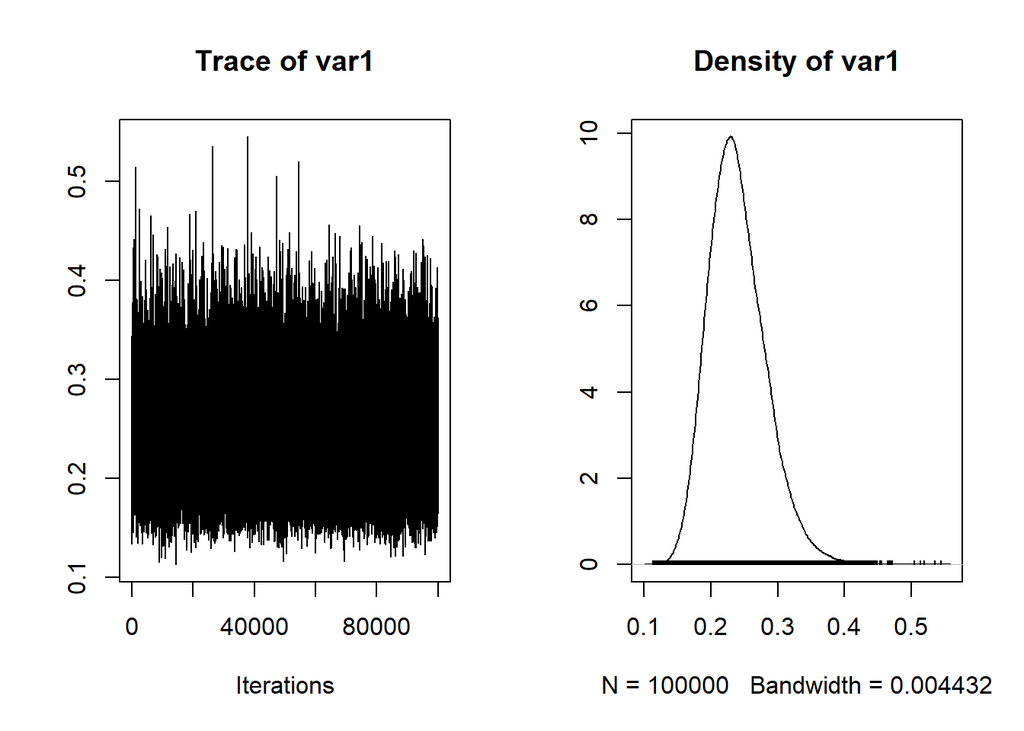

```r
par_mcmcglmm_max <- model_mcmcglmm_max$VCV[, "species"]
plot(par_mcmcglmm_max)
```

```r
# geweke.plot(par_mcmcglmm_max)
# geweke.diag(par_mcmcglmm_max)
# heidel.diag(par_mcmcglmm_max)
test <- raftery.diag(par_mcmcglmm_max)

# update your run parameters
NITT <- test$resmatrix[,"N"] + test$resmatrix[,"M"]
THIN <- ceiling(test$resmatrix[,"N"] / test$resmatrix[,"Nmin"])
BURNIN <- test$resmatrix[,"M"]

runtime_1_run <- benchmark(
    "process" = {
        model_mcmcglmm_1_run <- MCMCglmm(yi ~ x,
                        random = ~species + phylo,
                        family = "gaussian",
                        ginverse = list(phylo = phylo.prec.mat),
                        prior = prior,
                        data = dat,
                        verbose = FALSE,
                        nitt = NITT, burnin = BURNIN, thin = THIN
                        )
        }, replications = 1
)
```

### BRMS

“Reasonable” `brms` parameters.

```r
NITTb <- 10000
BURNINb <- 1000
THINb <- 1
CHAINS <- 1
```

Run a model that prepares the run but does not start actual sampling to have the baseline timing of the model pre-run protocols.

```r
runtime_2_pre <- benchmark(
    "process" = {
        model_brms_1_pre <- brm(yi ~ x + (1|species) + (1|gr(phylo, cov = phylo.mat)),
            data = dat,
            data2 = list(phylo.mat = phylo.mat),
            chains = CHAINS,
            iter = 2,
            warmup = 1,
            thin = 1
        )
    }, replications = 1
)
```

Run “larger” model and convert posterior to MCMC object.

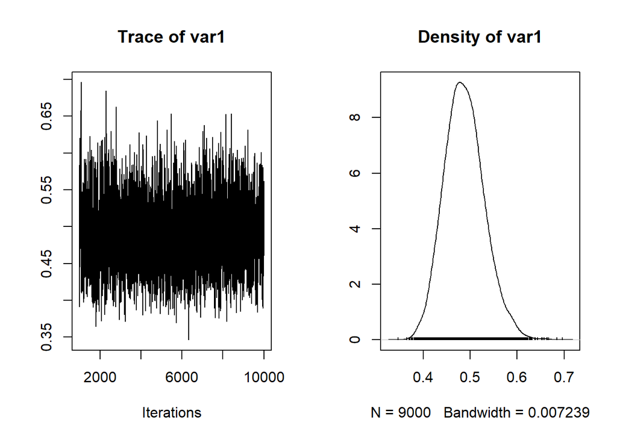

```r
model_brms_max <- brm(yi ~ x + (1|species) + (1|gr(phylo, cov = phylo.mat)),
            data = dat,
            data2 = list(phylo.mat = phylo.mat),
            chains = CHAINS,
            iter = NITTb,
            warmup = BURNINb,
            thin = THINb
)

summary(model_brms_max)

par_brms_max <- as.mcmc(model_brms_max, pars = "sd_species__Intercept")[[1]]
plot(par_brms_max)
```

```r
test <- raftery.diag(par_brms_max)

# update your run parameters
NITTb <- test$resmatrix[,"N"] + test$resmatrix[,"M"]
THINb <- ceiling(test$resmatrix[,"N"] / test$resmatrix[,"Nmin"])
BURNINb <- test$resmatrix[,"M"]

runtime_2_run <- benchmark(
    "process" = {
        model_brms_1_run <- brm(yi ~ x + (1|species) + (1|gr(phylo, cov = phylo.mat)),
            data = dat,
            data2 = list(phylo.mat = phylo.mat),
            chains = CHAINS,
            iter = NITTb,
            warmup = BURNINb,
            thin = THINb
        )
    }, replications = 1
)
```

### Summary runtimes

Summary table of runtimes for compilation and sampling:

```r
compil.perc.1 <- round(runtime_1_pre$elapsed / (runtime_1_pre$elapsed+runtime_1_run$elapsed) * 100, 1)
compil.perc.2 <- round(runtime_2_pre$elapsed / (runtime_2_pre$elapsed+runtime_2_run$elapsed) * 100, 1)
sampl.perc.1 <- round(runtime_1_run$elapsed / (runtime_1_pre$elapsed+runtime_1_run$elapsed) * 100, 1)
sampl.perc.2 <- round(runtime_2_run$elapsed / (runtime_2_pre$elapsed+runtime_2_run$elapsed) * 100, 1)

time.summary <- data.frame(
  model = c("MCMCglmm", "brms"),
  compilation.time = c(runtime_1_pre$elapsed, runtime_2_pre$elapsed),
  perc = c(compil.perc.1, compil.perc.2),
  sampling.time = c(runtime_1_run$elapsed - runtime_1_pre$elapsed, runtime_2_run$elapsed - runtime_2_pre$elapsed),
  perc = c(sampl.perc.1, sampl.perc.2)
)

kable(time.summary)
```

| model | compilation.time | perc | sampling.time | perc.1 |
| --- | --- | --- | --- | --- |
| MCMCglmm | 0.09 | 0.8 | 10.77 | 99.2 |
| brms | 159.00 | 38.1 | 99.67 | 61.9 |

# 4 Case studies

## 4.1 Background

The following case studies illustrate how phylogenetic mixed models can be applied to diverse questions in ecology and evolution. The first examines patterns of plumage colour in birds, while the second explores macroevolutionary patterns in plant traits. Together, they demonstrate the flexibility of these methods across taxa and research questions.

All models, results, and datasets presented in these case studies are **intended for illustrative purposes only**. They are designed to demonstrate analytical approaches rather than to provide definitive biological insights. No substantive conclusions should be drawn from these analyses.

## 4.2 Case study 1: Bird color evolution

Birds are a valuable system for studying ecological and evolutionary processes because their diversity in form, behaviour, and coloration is well documented across many species and habitats. Variation in plumage colour, in particular, can provide insights into mechanisms such as sexual selection, camouflage, and signalling. By examining these traits, researchers can better understand how environmental and evolutionary pressures shape biodiversity.

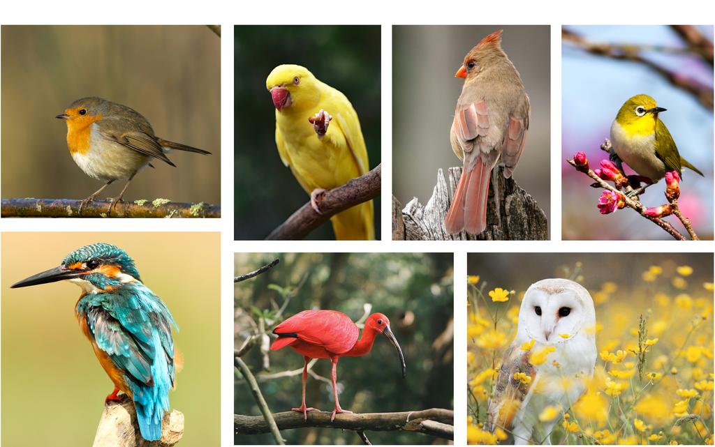

credits: Andy Chilton, Boris Smokrovic, David Clode, Jaime Spaniol, Joshua J. Cotte, Vincent Van Zalinge / unsplash.com.

### Data overview

Load data bird spectrum data:

```r
# Load bird spectrum data
bird_data <- read_delim("data/Spec_IndivReg.csv",
    delim = ";", escape_double = FALSE, locale = locale(decimal_mark = ","),
    trim_ws = TRUE)

# summary of birds species and genus
length(table(bird_data$genus_original)) # 446 genus
```

```
[1] 446
```

```r
length(table(bird_data$sci_name_Jetz)) # 949 species
```

```
[1] 949
```

```r
#length(table(bird_data$sci_name_original)) # 952 original species

# Remove the specified species from bird_data
bird_data <- bird_data |>
  filter(!sci_name_Jetz %in% c("Basileuterus_rufifrons", "Malurus_lamberti", "Malurus_splendens"))


########## Notes #########

# missing values ---> not sure why?
#na_count <- colSums(is.na(dat2))
#na_count[na_count > 0]

# individuals a-c are male and d-f are female
#table(bird_data$sex, bird_data$individual)

# number of measurements?
#table(bird_data$Nmeasured)

# duplicates per individual per body region
#dup <- dat |>
#    summarise(n = n(),
#              .by = c(wl, individual_nonrep, sex, body_region))
#r <- dup[which(dup$n>1),]
#table(r$individual_nonrep)
```

**Some notes:**

- The dataset contains data for 949 bird species, with 446 unique genera.
- Spectral values are normalised reflectance data.
- `Nmeasured` is the number of measurements per body patch.
- Each body region measured 5 times (then averaged).
- These species seem to have two measurements per body region per individual, which we remove to facilitate the analysis.:

  ```
  Basileuterus_rufifrons, Malurus_lamberti, Malurus_splendens
  ```

### Color data set-up

#### Obtain wavelength dataset

Now we want to create a wavelength dataset using the `pavo` package given the spectral reflectance data.

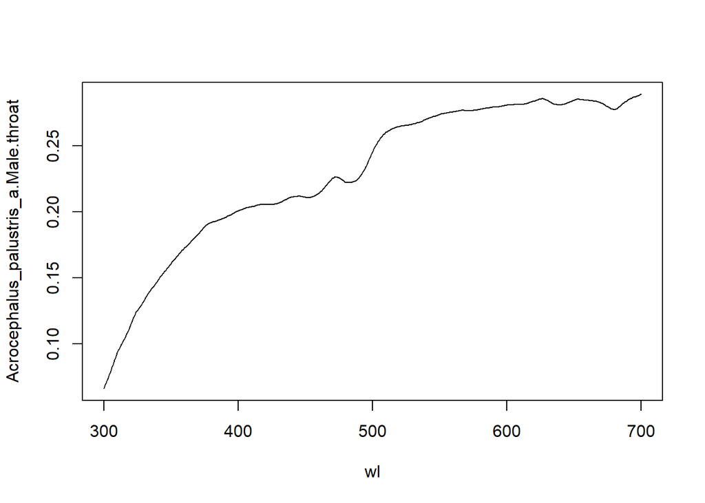

```r
# set up wavelength dataset (wavelengths columns 300 to 474)
dat <- bird_data |>
  pivot_longer(cols = `300`:`700`, names_to="wl", values_to="refl") |>
  dplyr::select(individual_nonrep, body_region, sex, wl, refl) |>
  mutate(wl = as.numeric(wl))

# pivot so each column is an individual body region measurement
dat2 <- dat |>
  pivot_wider(names_from = c("individual_nonrep", "sex", "body_region"),
              values_from = "refl", names_sep = ".")

# create spectral dataset with pavo
specs <- as.rspec(dat2)

# some examples of individual birds body region color spectrum
plot(Acrocephalus_palustris_a.Male.throat ~ wl, type="l", data=specs, title="Acrocephalus palustris (throat)")
```

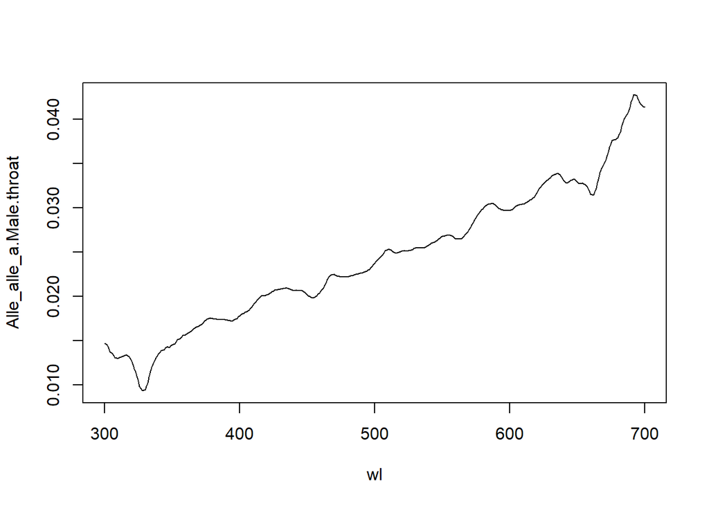

```r
plot(Alle_alle_a.Male.throat ~ wl, type="l", data=specs, title="Alle alle (throat)")
```

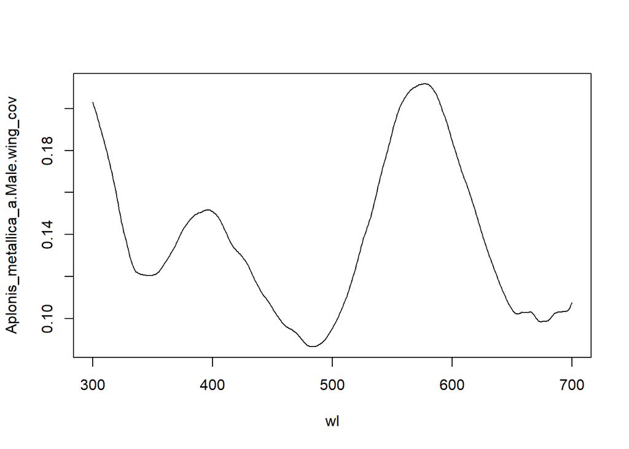

```r
plot(Aplonis_metallica_a.Male.wing_cov ~ wl, type = "l", data = specs, title="Aplonis metallica (wing covert)")
```

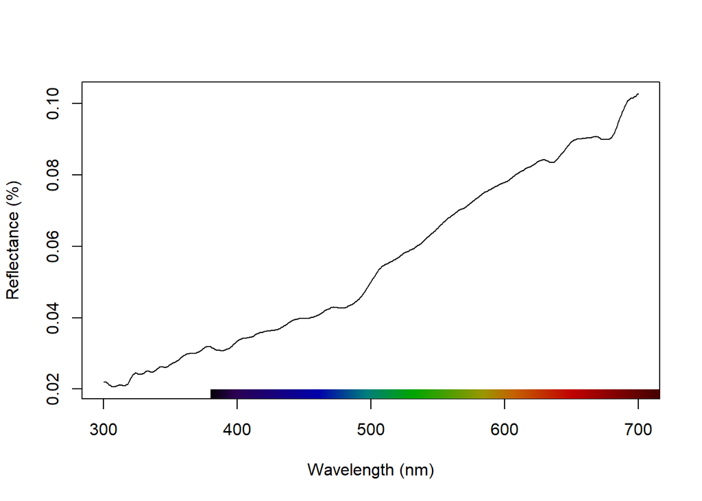

```r
# use procspec to adjust negative values by shifting them by 10
# (this maybe due to darker colors)
specs <- procspec(specs, fixneg="addmin")
plot(specs, select = 10)
```

#### Obtain spectral shape descriptors

```r
# Obtain spectral shape descriptors
spec.des <- summary(specs, subset = c("B1", "B2", "S9", "H4")) ## using subset makes it faster to run by selecting the shapes of interest

dev.off()
```

```r
# distribution of B1
ggplot(spec.des, aes(x = B1)) +
  geom_histogram(bins = 30, colour = "black", fill = "grey") +
  labs(x = "B1", title = "B1: Total brightness") +
  theme_bw()

# distribution of S9
ggplot(spec.des, aes(x = S9)) +
  geom_histogram(bins = 30, colour = "black", fill = "grey") +
  labs(x = "S9", title = "S9: Carotenoid chroma") +
  theme_bw()

# vdistribution o fH4
ggplot(spec.des, aes(x = H4)) +
  geom_histogram(bins = 30, colour = "black", fill = "grey") +
  labs(x = "H4", title = "H4: Hue (segment classification)") +
  theme_bw()
```

[output not shown]

The first dataset is the shape descriptors dataset, which we will use to model the continuous trait (brightness).

```r
spec.des$rowname <- rownames(spec.des)

spec.dat <- spec.des |>
  mutate(sex = case_when(
    grepl("Male", rowname) ~ "male",
    grepl("Female", rowname) ~ "female"),
    species = gsub("\\_[a-f]\\..*$", "", rowname),
    body_region = str_extract(rowname, "[a-z]+$")
  )

write.csv(spec.dat, file="data/spec_data_for_model.csv")
```

#### Obtain carotenoid datasets: binary and ordinal traits

We will use the carotenoid dataset to model the presence/absence of carotenoid coloration in birds. This dataset is based on the spectral reflectance data and the spectral shape descriptors.

Let’s set up the dataset for modelling a binary trait (absence/presence of carotenoid color):

```r
# 1) get human visual model (CIE 10 degree observed under D65 "day light")
vm <- vismodel(specs, visual = "cie10", illum = "D65", bkg = "ideal", relative = FALSE)

# 2) convert to CIELAB colorspace (to get hue and chroma)
lab <- colspace(vm, space = "cielab")

# 3) get chroma and hue angle (converting CIELAB to CIELCh)
L <- lab$L
a <- lab$a
b <- lab$b
C <- sqrt(a^2 + b^2)
h <- (atan2(b, a) * 180 / pi) %% 360  # degrees in 0 to 360

# 4) thresholds for carotenoid range and saturation
h_lower <- 330   # start of red
h_upper <- 100   # end of yellow
C_min   <- 15 # min chroma
L_min   <- 20 # avoid very dark samples

# 5) Hue range test
in_range <- h >= h_lower | h <= h_upper

# 6) COmpute binary trait:  1 = carotenoid like colour present, 0 = absent
present <- as.integer(in_range & C >= C_min & L >= L_min)

# set up dataset
carot.dat.all <- data.frame(
  rowname  = rownames(lab),
  L = L, a = a, b = b, C = C, h = h,
  carotenoid = present
)

# merge with spec.data based on "rowname" column
carot.dat.all <- merge(spec.dat, carot.dat.all, by.x = "rowname", by.y = "rowname", all = TRUE)
# create individual id variable
carot.dat.all$indiv_rep <- sub(".*_([a-f])\\..*$", "\\1", carot.dat.all$rowname)

# number of observations with carotenoid like colour
table(carot.dat.all$carotenoid)
```

```
    0     1
33520   506
```

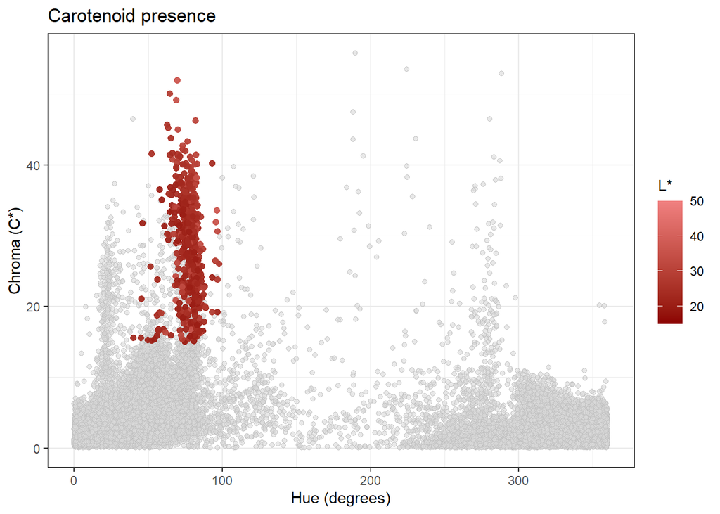

```r
# # checks
# carot.dat.all |>
#   filter(L>20 & C>12 & in_range) |>
#   arrange(desc(L))

# #  check bird cardinalis cardinalis (should be yellow or red?)
# carot.dat.all |>
#   filter(grepl("Cardinalis_cardinalis", rowname)) |>
#   arrange(desc(h))


# Plot
ggplot(carot.dat.all, aes(h, C)) +
  geom_point(data = subset(carot.dat.all, carotenoid == 0),
             shape = 21, size = 1.5, fill = "grey85", colour = "grey70", alpha = 0.6) +
  geom_point(data = subset(carot.dat.all, carotenoid == 1),
             aes(fill = L, colour = L), shape = 21, size = 1.8, stroke = 0.4, alpha = 0.95) +
  scale_fill_gradient(name = "L*", limits = c(15, 50), low = "darkred", high = "lightcoral") +
  scale_colour_gradient(guide = "none", limits = c(15, 50), low = "darkred", high = "lightcoral") +
  labs(x = "Hue (degrees)", y = "Chroma (C*)", title = "Carotenoid presence") +
  theme_bw()
```

Let’s save the dataset for modelling later on:

```r
carot.dat <- carot.dat.all

# save as csv
write.csv(carot.dat, file="data/carotenoid_data_for_model.csv", row.names = FALSE)
```

Now let’s obtain the dataset where we summarise for each individual bird the proportion of body region with carotenoid color presence (ordinal data trait), and save it for modelling later on:

```r
carot.ordinal <- carot.dat.all |>
  group_by(species, sex, indiv_rep) |>
  summarise(prop_carotenoid = mean(carotenoid), .groups = "drop")

# save as csv
write.csv(carot.ordinal, file="data/ordinal_data_for_model.csv", row.names = FALSE)
```

### Phylogenetic correlation matrix set-up

Load and view phylogenetic tree:

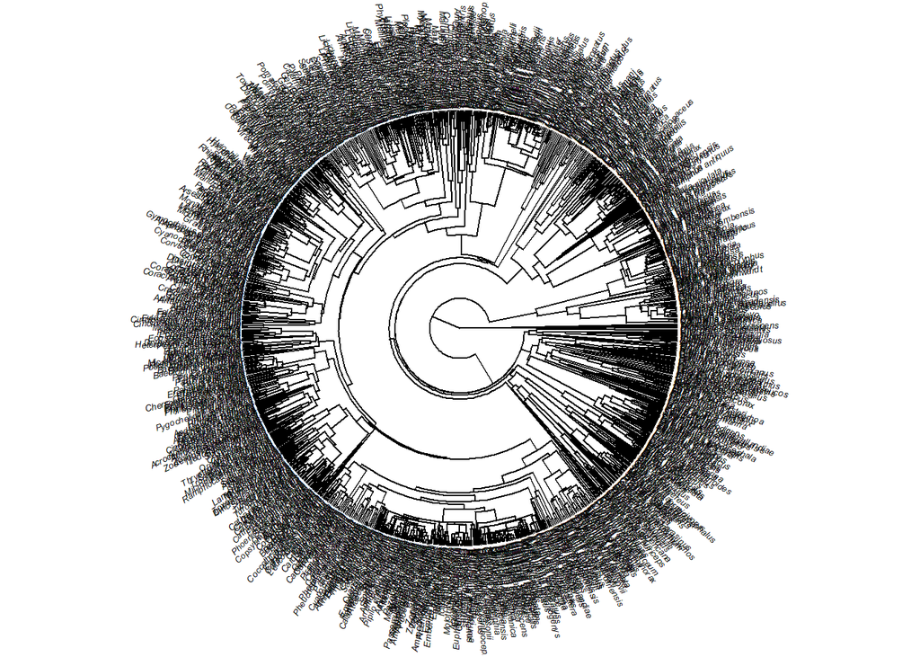

```r
# Load bird tree (consensus tree = "combined tree")
bird.tree <- read.tree("data/Stage2_Hackett_MCC_no_neg.tre")

### Prune bird tree
bird.pruned <- keep.tip(bird.tree, bird_data$sci_name_Jetz)
# check whether names match in data and tree
check <- name.check(bird.pruned, bird_data$sci_name_Jetz, sort(bird.pruned$tip.label))

# plot tree
plotTree(bird.pruned, ftype="i", fsize=0.4, lwd=1, type="fan")
```

```r
dev.off()
```

Set up correlation matrix for glmmTMB model and check it corresponds to the species labels in the data:

```r
# set up phylogenetic correlation matrix
phylo.mat <- vcv(bird.pruned, corr = TRUE)
phylo.mat <- phylo.mat[sort(rownames(phylo.mat)), sort(rownames(phylo.mat))]
saveRDS(phylo.mat, file = "data/phylo_matrix.rds")


# checks
# length(colnames(phylo.mat))==length(table(spec.dat$species))
# all(head(rownames(phylo.mat))==head(colnames(phylo.mat)))
# head(table(spec.dat$species))
```

### Model 1. Continuous trait

```r
# load data
spec.dat <- read_csv("data/spec_data_for_model.csv")
phylo.mat <- readRDS("data/phylo_matrix.rds")

# load library
library(glmmTMB)

# add grouping variable (set it to 1) - this is necessary to fit the glmmTMB model
spec.dat$g <- 1
```

##### Modelling total brightness (B1)

1. Gaussian to model $\log(B1)$
2. Gamma with a log link to model $B1$

For each model we will examine simulated standardised residuals using to assess nonlinearity and heteroscedasticity. If two or more models perform similarly, we will prefer the model with clearer interpretation on the original scale.

```r
# Fit models --------------

# normal
time_norm <- system.time(
  m1 <- glmmTMB(log(B1) ~ body_region * sex + (1|species) + propto(0 + species|g,phylo.mat),
                      family = gaussian(),
                      data = spec.dat)
  )

# Gamma distribution
time_gamma <- system.time(
  m2 <- glmmTMB(B1 ~ body_region * sex + (1|species) + propto(0 + species|g,phylo.mat),
                      family = Gamma(link = "log"),
                      data = spec.dat)
)

# Get model info  ---------------------------
# check whether model has postive definite hessian

b1_output <- data.frame(
  model = c("Gaussian (log)", "Gamma"),
  convergence = c(m1$sdr$pdHess, m2$sdr$pdHess),
  runtime = c(time_norm[["elapsed"]], time_gamma[["elapsed"]])
)

b1_output
```

```
           model convergence runtime
1 Gaussian (log)        TRUE   405.0
2          Gamma        TRUE   475.6
```

##### Model diagnostics

Let’s check residual plots with the DHARMa packages. First, the log(B1) assuming normal distribution residual checks:

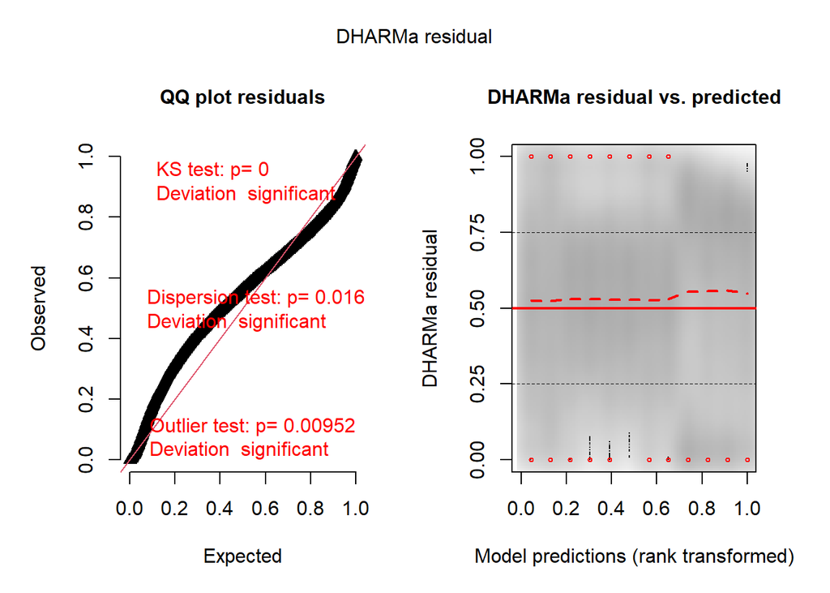

```r
res_gauss <- DHARMa::simulateResiduals(fittedModel = m1)
plot(res_gauss)
```

The model checks assuming Gamma distribution and log link function:

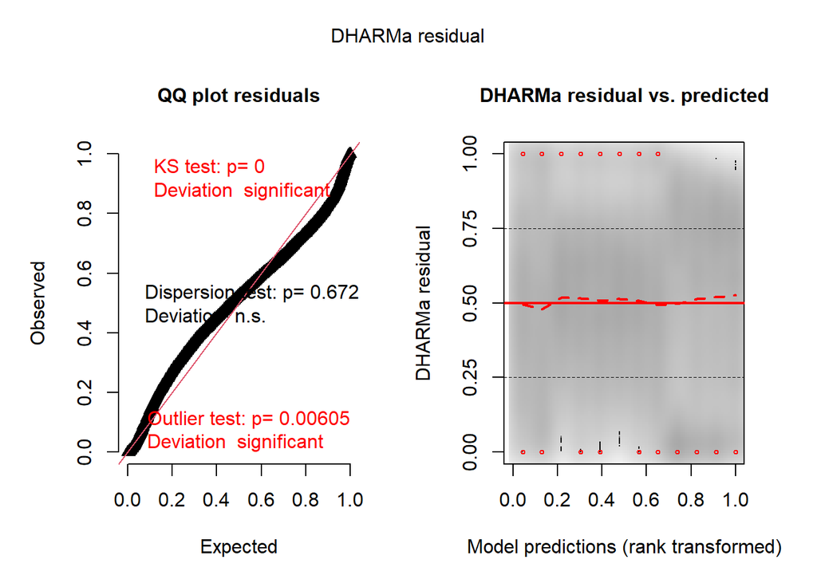

```r
res_gamma <- DHARMa::simulateResiduals(fittedModel = m2)
plot(res_gamma)
```

We found that the Gamma distribution shows improve model fit in the residual plots.

##### Model estimates

Let’s obtain the estimate of the phylogenetic signal and non-phylogenetic signal for the Gamma model:

```r
# get random effect component estimates on SD-scale
m2_re <- as.data.frame(confint(m2, parm="theta_"))
sigma2_s <- m2_re$Estimate[1]^2 # non-phylogenetic variance
sigma2_p <- m2_re$Estimate[2]^2 # phylogenetic variance estimate

p.signal <- sigma2_p / (sigma2_p + sigma2_s)
p.signal
```

```
[1] 0.842
```

```r
np.signal <- 1-p.signal
np.signal
```

```
[1] 0.158
```

On the log mean scale of the Gamma model, the phylogenetic species effect explained 84.2% of the total species level random effect variance i.e. this represents the degree of phylogenetic signal in the overall variance sourced from species. The non-phylogenetic effect explained 15.8% of the total species level random effect variance.

We can obtain and compare the residual variances for each model with the following:

```r
# residual variance of gaussian model
m1_res.var <- sigma(m1)^2

# residual variance of gamma model
phi <- sigma(m2)^2 #phi given on SD-scale
scale <- 1/phi #derive scale parameter
m2_res.var <- trigamma(scale)

# print
data.frame(
  model = c("Gaussian (log)", "Gamma"),
  residual_variance = c(m1_res.var, m2_res.var)
)
```

```
           model residual_variance
1 Gaussian (log)            0.3265
2          Gamma            0.3319
```

To assess differences in total brightness between sexes for each body region, we compute marginal means from the fitted model and perform pairwise comparisons between females and males. The resulting ratios (female/male) and their confidence intervals are then plotted to visualise the magnitude and direction of differences across body regions.

```r
emm_b1 <- emmeans(m2, ~ sex | body_region, type = "response")

# get contrasts (ratios) back transformed on response scale with CI
b1_sex_diff <- contrast(emm_b1, method = "pairwise", reverse=TRUE) |>
  summary(infer = TRUE, type = "response")

b1_sex_diff
```

```
body_region = back:
 contrast      ratio     SE  df asymp.LCL asymp.UCL null z.ratio p.value
 female / male 0.973 0.0139 Inf     0.946     1.000    1  -1.923  0.0545

body_region = belly:
 contrast      ratio     SE  df asymp.LCL asymp.UCL null z.ratio p.value
 female / male 1.069 0.0153 Inf     1.040     1.100    1   4.708 <0.0001

body_region = cov:
 contrast      ratio     SE  df asymp.LCL asymp.UCL null z.ratio p.value
 female / male 0.998 0.0143 Inf     0.970     1.026    1  -0.141  0.8882

body_region = crown:
 contrast      ratio     SE  df asymp.LCL asymp.UCL null z.ratio p.value
 female / male 0.912 0.0131 Inf     0.887     0.938    1  -6.390 <0.0001

body_region = tail:
 contrast      ratio     SE  df asymp.LCL asymp.UCL null z.ratio p.value
 female / male 1.020 0.0145 Inf     0.992     1.050    1   1.426  0.1537

body_region = throat:
 contrast      ratio     SE  df asymp.LCL asymp.UCL null z.ratio p.value
 female / male 1.075 0.0154 Inf     1.046     1.106    1   5.099 <0.0001

Confidence level used: 0.95
Intervals are back-transformed from the log scale
Tests are performed on the log scale
```

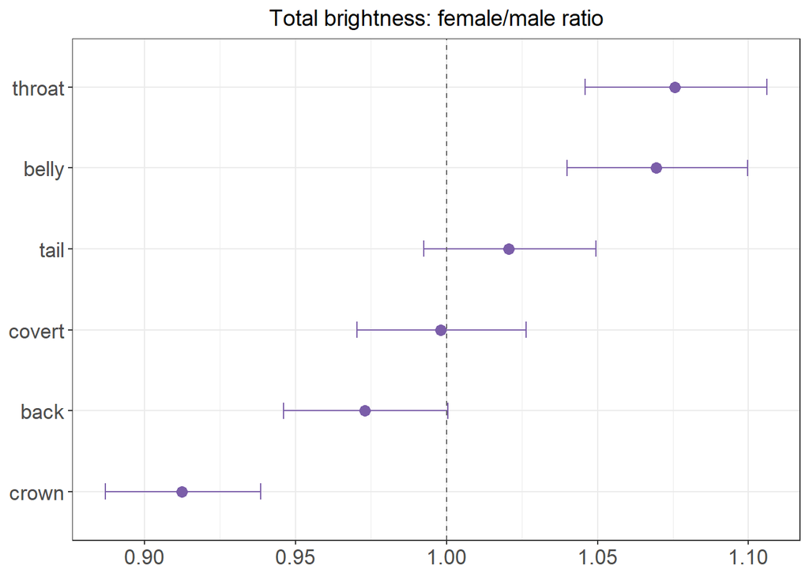

```r
## plot pairwise differences between female and male total brightness
b1_plot <- b1_sex_diff |>
  arrange(ratio) |>
  mutate(
    body_region = gsub("cov", "covert", body_region),  # replace "cov" with "covert"
    body_region = factor(body_region, unique(body_region), ordered = TRUE)
  ) |>
  ggplot(aes(y = body_region, x = ratio)) +
  geom_point(size = 3, colour = "#7B5EA9") +
  geom_errorbar(aes(xmin = asymp.LCL, xmax = asymp.UCL),
                width = 0.2, colour = "#7B5EA9") +
  geom_vline(xintercept = 1, linetype = "dashed", colour = "grey40") +
  labs(
    y = NULL,
    x = NULL,
    title = "Total brightness: female/male ratio"
  ) +
  theme_bw() +
  theme(
    legend.position = "none",
    axis.text.x = element_text(size = 13),
    axis.text.y = element_text(size = 13),
    plot.title = element_text(size = 14, hjust = 0.5)
  )
b1_plot
```

```r
ggsave("b1_plot.png", plot = b1_plot, width = 7, height = 5)
```

Ratios $>1$ indicate greater brightness in females, while ratios $<1$ indicate greater brightness in males.

### Model 2. Binary trait

Binary colour traits, such as the presence of carotenoid colours, may be associated with distinct evolutionary and ecological drivers.

Here we want to model the absence or presence of carotenoid across all body regions accounting for sex and including species- and phylogeny-level random effects. We will use the carotenoid dataset which we obtained earlier.

##### Modelling carotenoid presence

We will fit two models: - Binomial model with a logit link function - Beta binomial model with a logit link function

```r
# Fit models --------------

# load dat
carot.dat <- read_csv("data/carotenoid_data_for_model.csv")
carot.dat$g <- 1

# binomial model
time_binom <- system.time(
  m3 <- glmmTMB(carotenoid ~ body_region * sex + (1|species) + propto(0 + species|g,phylo.mat),
                family = binomial(link = "logit"),
                data = carot.dat)
)

# beta binomial
time_bbinom <- system.time(
  m4 <- glmmTMB(carotenoid ~ body_region * sex + (1|species) + propto(0 + species|g,phylo.mat),
                family = betabinomial(link = "logit"),
                data = carot.dat)
)

# Get model info -----------

carotmod_output <- data.frame(
  model = c("Binomial", "Beta binomial"),
  convergence = c(m3$sdr$pdHess, m4$sdr$pdHess),
  runtime = c(time_binom[["elapsed"]], time_bbinom[["elapsed"]]),
  AIC = c(AIC(m3), AIC(m4))
)
carotmod_output
```

```
          model convergence runtime  AIC
1      Binomial        TRUE   293.8 3094
2 Beta binomial       FALSE   866.1   NA
```

##### Model diagnostics

Let’s check residual plots with the DHARMa packages. First, let’s get the residual plots for the binomial model:

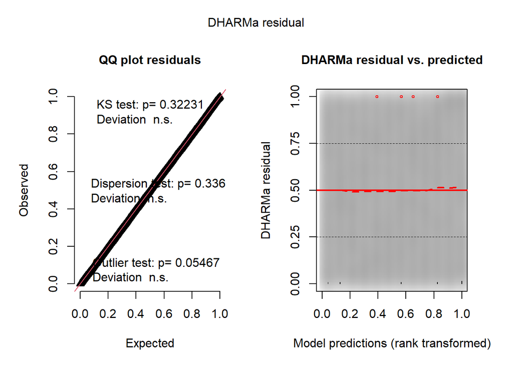

```r
res_binom <- DHARMa::simulateResiduals(fittedModel = m3)
plot(res_binom)
```

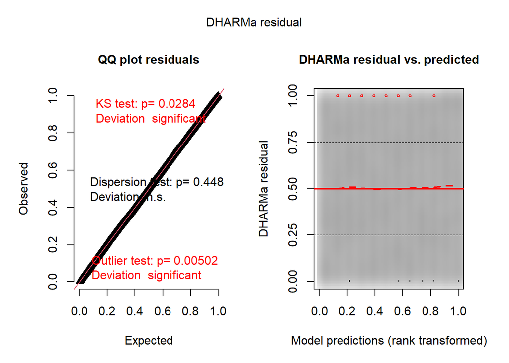

```r
res_bbinom <- DHARMa::simulateResiduals(fittedModel = m4)
plot(res_bbinom)
```

##### Model estimates

Let’s obtain the estimate of the phylogenetic signal for this model:

```r
# get random effect component estimates on SD-scale
m3_re <- as.data.frame(confint(m3, parm="theta_"))

sigma2_s <- m3_re$Estimate[1]^2 # non-phylogenetic variance
sigma2_p <- m3_re$Estimate[2]^2 # phylogenetic variance estimate

p.signal <- sigma2_p / (sigma2_p + sigma2_s)
p.signal
```

```
[1] 0.9243
```

Get model estimated marginals means on the response scale:

```r
# Estimated marginal means on the response scale (odds)
emm_m3 <- emmeans(m3, ~ sex | body_region, type = "response")

# get contrasts (odds ratios)
m3_sex_prob <- contrast(emm_m3, method = "pairwise", reverse=TRUE) |>
  summary(infer = TRUE, type = "response")

# Put into data frame for plotting
sex_prob_df <- as.data.frame(m3_sex_prob) |>
  rename(ratio = odds.ratio, lower.CL = asymp.LCL, upper.CL = asymp.UCL)
sex_prob_df
```

```
body_region = back:
 contrast       ratio      SE  df lower.CL upper.CL null z.ratio p.value
 female / male 0.0000 0.00005 Inf   0.0000      Inf    1  -0.007  0.9947

body_region = belly:
 contrast       ratio      SE  df lower.CL upper.CL null z.ratio p.value
 female / male 0.9353 0.13585 Inf   0.7036        1    1  -0.460  0.6453

body_region = cov:
 contrast       ratio      SE  df lower.CL upper.CL null z.ratio p.value
 female / male 0.4490 0.21091 Inf   0.1788        1    1  -1.705  0.0883

body_region = crown:
 contrast       ratio      SE  df lower.CL upper.CL null z.ratio p.value
 female / male 0.7303 0.24013 Inf   0.3834        1    1  -0.956  0.3391

body_region = tail:
 contrast       ratio      SE  df lower.CL upper.CL null z.ratio p.value
 female / male 0.5335 0.27658 Inf   0.1931        1    1  -1.212  0.2255

body_region = throat:
 contrast       ratio      SE  df lower.CL upper.CL null z.ratio p.value
 female / male 0.7066 0.18028 Inf   0.4285        1    1  -1.361  0.1734

Confidence level used: 0.95
Intervals are back-transformed from the log odds ratio scale
Tests are performed on the log odds ratio scale
```

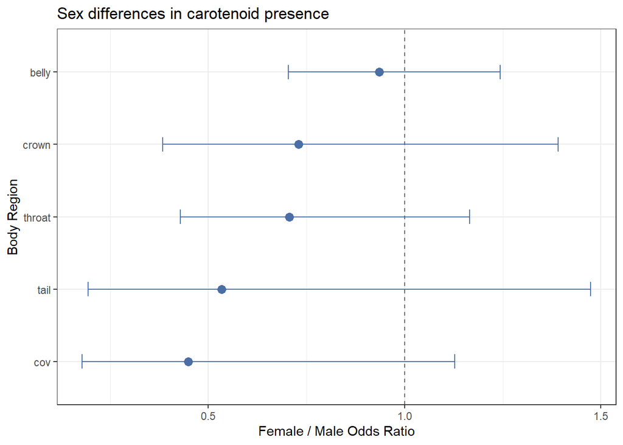

```r
# Plot
sex_prob_df |>
  arrange(ratio) |>
  filter(!(body_region=="back")) |>
  mutate(body_region = factor(body_region, unique(body_region), ordered = TRUE)) |>
  ggplot(aes(y = body_region, x = ratio, colour = body_region)) +
  geom_point(size = 3, colour = "#4B6EA5") +
  geom_errorbar(aes(xmin = lower.CL, xmax = upper.CL),
                width = 0.2, colour = "#4B6EA5") +
  geom_vline(xintercept = 1, linetype = "dashed", colour = "grey40") +
  labs(y = "Body Region", x = "Female / Male Odds Ratio",
       title = "Sex differences in carotenoid presence") +
  theme_bw() +
  theme(legend.position = "none")
```

### Model 3. Ordinal trait

##### Modelling carotenoid proportion per body region

```r
# load data
ord.dat <- read_csv("data/ordinal_data_for_model.csv")
ord.dat$g <- 1 # add grouping variable

# fit model
time_ord <- system.time(
  m5 <- glmmTMB(prop_carotenoid ~ sex + (1|species) + propto(0 + species|g,phylo.mat),
                  family = ordbeta(),
                  data = ord.dat)
)

# output
data.frame(
  model = "Ordinal beta",
  convergence = m5$sdr$pdHess,
  runtime = time_ord[["elapsed"]],
  AIC = AIC(m5)
)
```

```
         model convergence runtime   AIC
1 Ordinal beta        TRUE   284.4 764.1
```

##### Model diagnostics

Look at residual diagnostic plots:

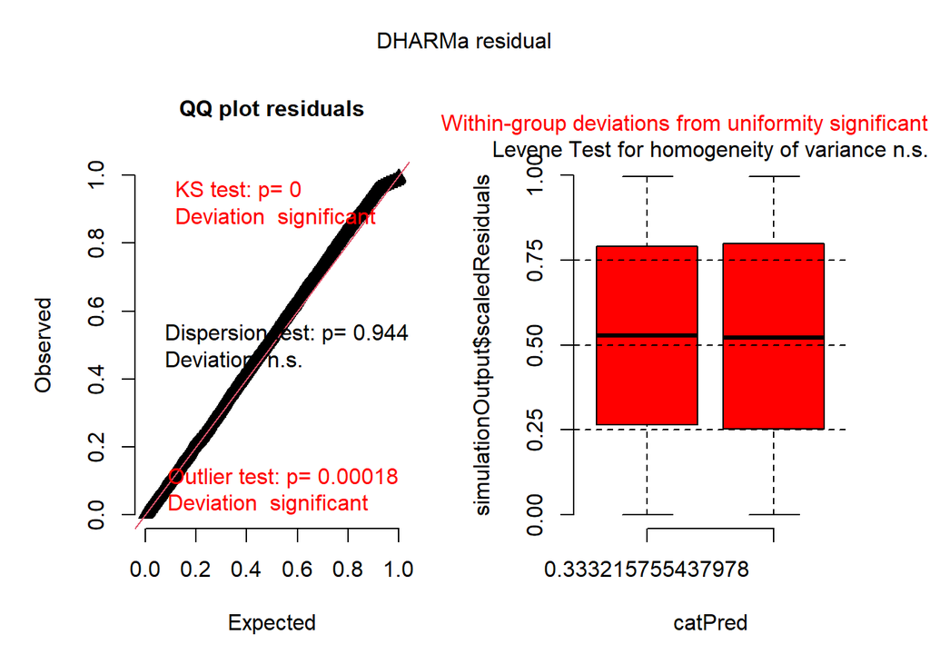

```r
res_ord <- DHARMa::simulateResiduals(fittedModel = m5)
plot(res_ord)
```

##### Model estimates

Phylogenetic signal:

```r
# get random effect component estimates on SD-scale
m5_re <- as.data.frame(confint(m5, parm="theta_"))

sigma2_s <- m5_re$Estimate[1]^2 # non-phylogenetic variance est.
sigma2_p <- m5_re$Estimate[2]^2 # phylogenetic variance est.

p.signal.m5 <- sigma2_p / (sigma2_p + sigma2_s)
p.signal.m5
```

```
[1] 0.9666
```

```r
emm_m5 <- emmeans(m5, ~ sex, type = "response")

# pairwise contrast: Female vs Male
m5_sex_OR <- contrast(emm_m5, method = "pairwise") |>
  summary(infer = TRUE, type = "response")

# get summary with CI
sex_OR <- as.data.frame(m5_sex_OR) |>
  rename(OR = odds.ratio, lower.CL = asymp.LCL, upper.CL = asymp.UCL)

sex_OR
```

```
 contrast          OR     SE  df lower.CL upper.CL null z.ratio p.value
 female / male 0.9169 0.0246 Inf   0.8699   0.9664    1  -3.235  0.0012

Confidence level used: 0.95
Intervals are back-transformed from the log odds ratio scale
Tests are performed on the log odds ratio scale
```

## 4.3 Case study 2: Evolution of plant hydraulic traits

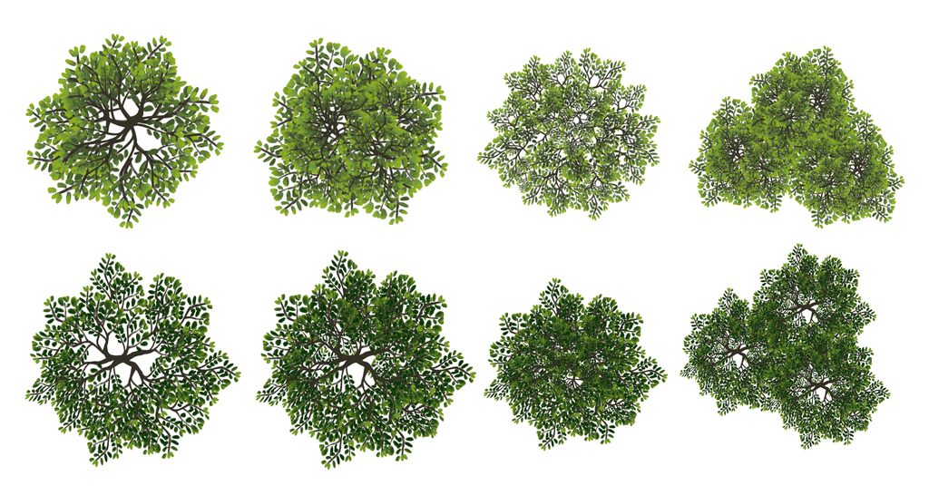

credits: Chanya_B / stock.adobe.com

### Data overview

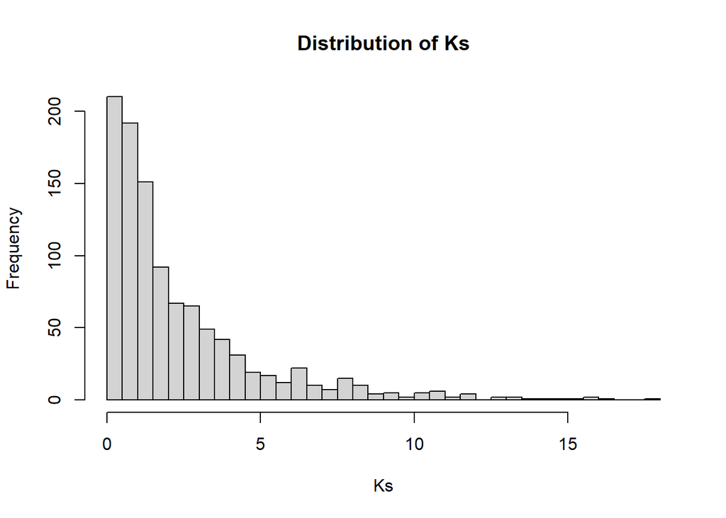

```r
# Load plant hydraulic traits dataset
hydra.dat <- read_csv("data/HydraEvol2020.csv")

# Have a look at distribution of traits
hist(hydra.dat$Ks, breaks = 50, main = "Distribution of Ks", xlab = "Ks")
```

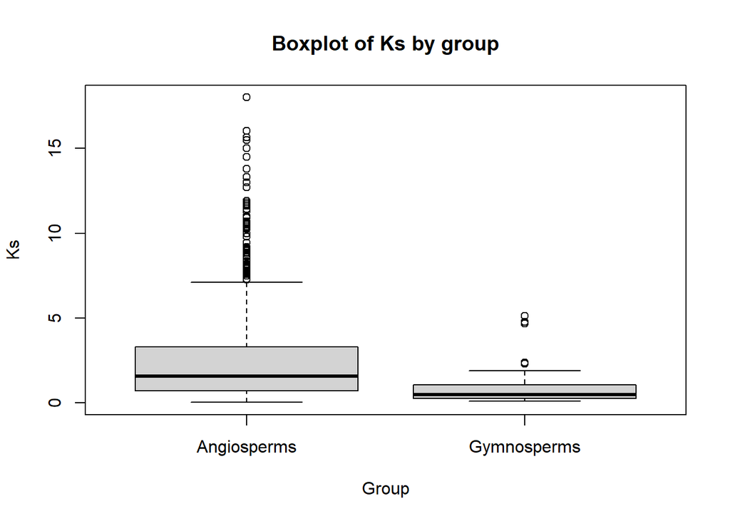

```r
boxplot(hydra.dat$Ks ~ hydra.dat$group, main = "Boxplot of Ks by group", xlab = "Group", ylab = "Ks")
```

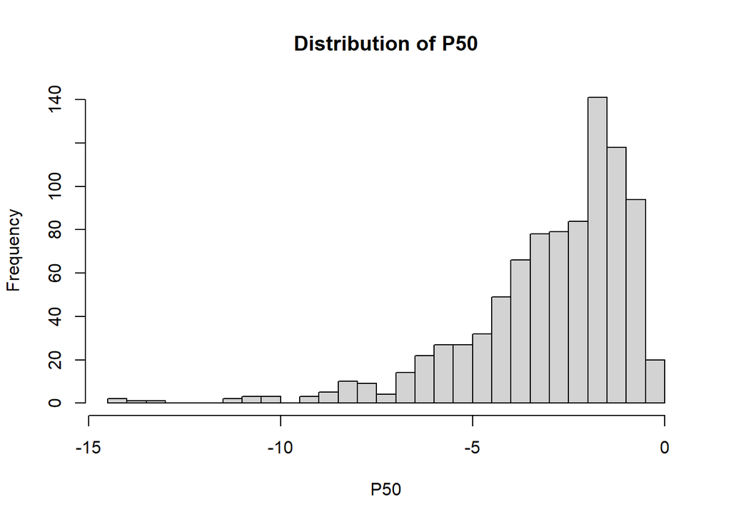

```r
hist(hydra.dat$P50, breaks = 50, main = "Distribution of P50", xlab = "P50")
```

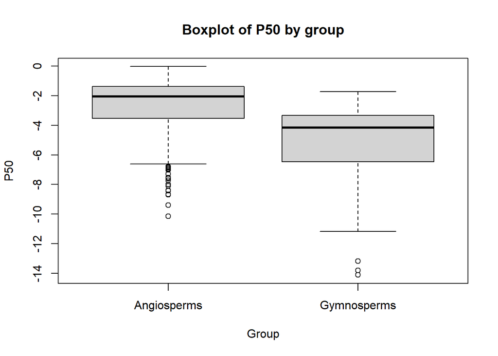

```r
boxplot(hydra.dat$P50 ~ hydra.dat$group, main = "Boxplot of P50 by group", xlab = "Group", ylab = "P50")
```

### Phylogenetic tree

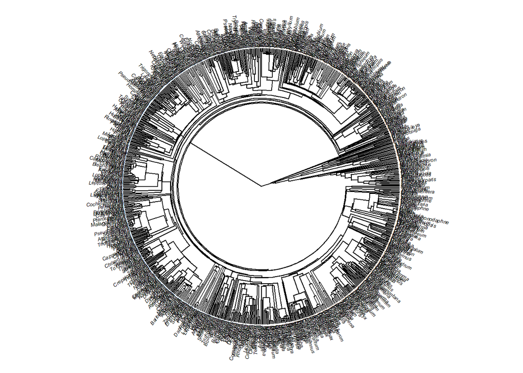

```r
# Load tree
plant.tree <- ape::read.tree("data/genus-level_phylogeny.tre")

# plot tree
plotTree(plant.tree, ftype="i", fsize=0.4, lwd=1, type="fan")
```

```r
dev.off()
```

### 1. Model for kS

Plant species with high saturated hydraulic conductivity (kS) are able to transport water through their xylem more efficiently, and are therefore characterised as highly efficient in water transport.

First let’s set up the models for glmmTMB:

- Log(response) Gaussian.
- Gamma model.

First, let’s set up the phylogenetic correlation matrix for the `glmmTMB` model and the inverse matrix for `MCMCglmm`.

We want to obtain a phylogenetic matrix that match all genera in the Ks dataset.m We will therefore remove all missing entries for the `Ks` trait and prune the tree and the dataset to have the same genera in both.

```r
# create dat for ks (remove all missing values)
ks.dat <- subset(hydra.dat, !is.na(Ks))
all(is.na(ks.dat$genus))
```

```
[1] FALSE
```

```r
# get common genus dataset and tree
common.genus <- intersect(plant.tree$tip.label, ks.dat$genus)

# Prune tree
plant.tree.pruned <- ape::drop.tip(plant.tree, setdiff(plant.tree$tip.label, common.genus))
#length(plant.tree.pruned$tip.label)

# Prune dataset
ks.dat <- ks.dat[ks.dat$genus %in% common.genus, ]
#length(table(ks.dat$genus))

# check whether names match in data and tree
check <- geiger::name.check(plant.tree.pruned, ks.dat$genus, sort(plant.tree.pruned$tip.label))

# set up phylogenetic correlation matrix
phylo.mat.p <- vcv(plant.tree.pruned, corr = TRUE)
phylo.mat.p <- phylo.mat.p[sort(rownames(phylo.mat.p)), sort(rownames(phylo.mat.p))]

# set up inverse phylogenetic correlation matrix for MCMCglmm
phylo.inv <- MCMCglmm::inverseA(plant.tree.pruned, nodes = "TIPS")$Ainv
phylo.inv <- phylo.inv[sort(rownames(phylo.inv)),]

# checks
# length(colnames(phylo.mat.p))==length(table(ks.dat$genus))
# all(head(rownames(phylo.mat.p))==head(colnames(phylo.mat.p)))
# length(rownames(phylo.inv))==length(table(ks.dat$genus))
# head(table(ks.dat$genus))
```

```r
# make sure to add grouping factor for glmmTMB
ks.dat$g <- 1
ks.dat$genus <- as.factor(ks.dat$genus)


# Fit models --------------

# normal
time_norm <- system.time(
  m6 <- glmmTMB(log(Ks) ~ group + (1|genus) + propto(0 + genus|g, phylo.mat.p),
                      family = gaussian(),
                      REML=TRUE,
                      data = ks.dat)
  )

# Gamma distribution
time_gamma <- system.time(
  m7 <- glmmTMB(Ks ~ group + (1|genus) + propto(0 + genus|g,phylo.mat.p),
                      family = Gamma(link = "log"),
                      data = ks.dat)
)
```

#### Diagnostic plots

Let’s check residual plots with the DHARMa packages. First, the log(Ks) assuming normal distribution residual checks:

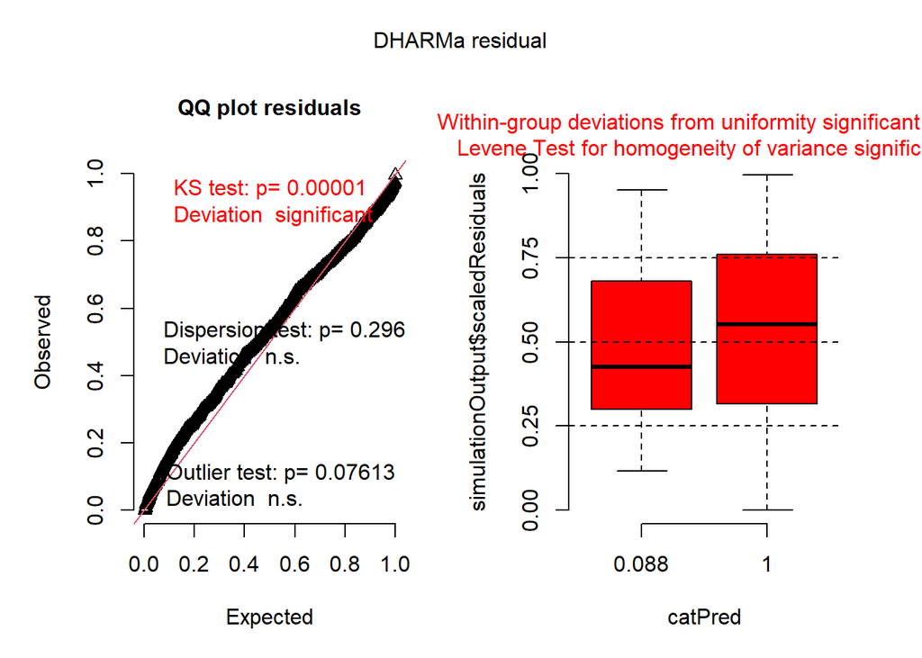

```r
res_norm <- DHARMa::simulateResiduals(fittedModel = m6)
plot(res_norm)
```

The model checks assuming Gamma distribution and log link function:

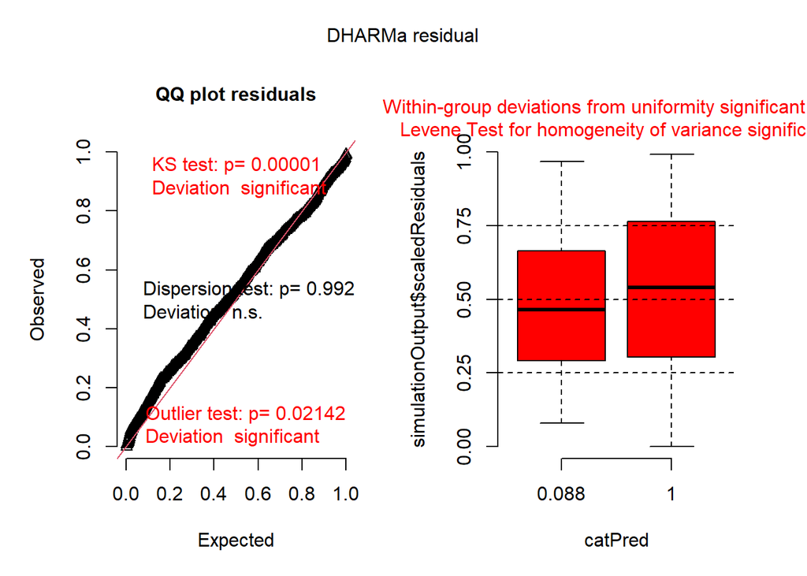

```r
res_gamma2 <- DHARMa::simulateResiduals(fittedModel = m7)
plot(res_gamma2)
```

Residual diagnostics are relatively similar.

#### Results

Get phylogenetic signal from glmmTMB Gaussian model:

```r
# get random effect component estimates on SD-scale
m6_re <- as.data.frame(confint(m6, parm="theta_"))
sigma2_s <- m6_re$Estimate[1]^2 # non-phylogenetic variance
sigma2_p <- m6_re$Estimate[2]^2 # phylogenetic variance estimate

p.signal <- sigma2_p / (sigma2_p + sigma2_s)
p.signal
```

```
[1] 0.8391
```

We found that the phylogenetic species effect explained 83.9% of the total species level random effect variance, and hence the non-phylogenetic effect explained only 16.1% of the total species level random effect variance.

Get model estimated marginals means on the response scale:

```r
# Estimated marginal means on the response scale (odds)
emm_m6 <- emmeans(m6, ~ group, type = "response")
emm_m6
```

```
 group       response    SE  df asymp.LCL asymp.UCL
 Angiosperms     1.22 0.938 Inf     0.271      5.50
 Gymnosperms     0.62 0.307 Inf     0.235      1.64

Confidence level used: 0.95
Intervals are back-transformed from the log scale
```

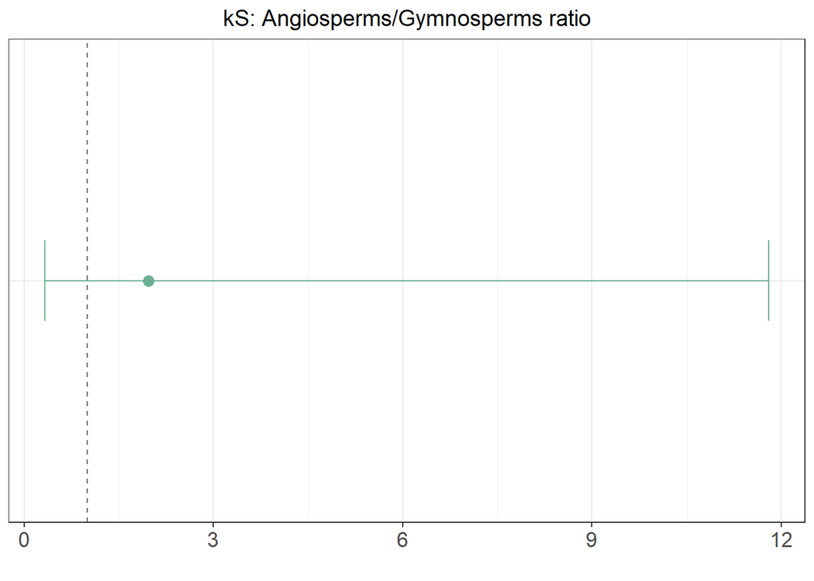

```r
# Get the contrast between the two groups
group_diff <- contrast(emm_m6, method = "pairwise", reverse=TRUE) |>
  summary(infer = TRUE, type = "response")


# Plot
kS_plot <-
  ggplot(group_diff, aes(y = contrast, x = ratio)) +
  geom_point(size = 3, colour = "#6BAF92") +
  geom_errorbar(aes(xmin = asymp.LCL, xmax = asymp.UCL),
                width = 0.2, colour = "#6BAF92") +
  geom_vline(xintercept = 1, linetype = "dashed", colour = "grey40") +
  labs(y = NULL, x = "",
       title = "kS: Angiosperms/Gymnosperms ratio") +
  theme_bw() +
  theme(legend.position = "none") +
  theme(
    legend.position = "none",
    axis.text.x = element_text(size = 13),
    axis.text.y = element_blank(),
    axis.ticks.y = element_blank(),
    plot.title = element_text(size = 14, hjust = 0.5)
  )
kS_plot
```

```r
ggsave("kS_plot.png", plot = kS_plot, width = 5, height = 3)
```

### 2. Model for P50

P50 represents the level of water stress at which a tree experiences a 50% loss of hydraulic conductivity. More negative P50 values indicate that trees can withstand greater hydraulic stress before suffering hydraulic damage, so communities with lower P50s are considered more resilient to increasing water stress (Trugman et al., 2020).

First let’s set up the models for glmmTMB:

- Try gamma model
- Log(response) gaussian

```r
# create dat for ks (remove all missing values)
p50.dat <- subset(hydra.dat, !is.na(P50))

# create negative P50 variable
p50.dat$negP50 <- - p50.dat$P50

# get common genus across dataset and tree
common.genus <- intersect(plant.tree$tip.label, p50.dat$genus)

# Prune dataset
p50.dat <- p50.dat[p50.dat$genus %in% common.genus, ]

# Prune tree
plant.tree.pruned <- ape::drop.tip(plant.tree, setdiff(plant.tree$tip.label, common.genus))

# check whether names match in data and tree
check <- geiger::name.check(plant.tree.pruned, p50.dat$genus, sort(plant.tree.pruned$tip.label))

# set up phylogenetic correlation matrix
phylo.mat.p <- vcv(plant.tree.pruned, corr = TRUE)
phylo.mat.p <- phylo.mat.p[sort(rownames(phylo.mat.p)), sort(rownames(phylo.mat.p))]

# set up inverse phylogenetic correlation matrix for MCMCglmm
phylo.mat.p.inv <- solve(phylo.mat.p)


# checks
# length(colnames(phylo.mat.p))==length(table(p50.dat$genus))
# all(head(rownames(phylo.mat.p))==head(colnames(phylo.mat.p)))
# head(table(p50.dat$genus))
```

```r
# make sure to add grouping factor for glmmTMB
p50.dat$g <- 1
p50.dat$genus <- as.factor(p50.dat$genus)


# Fit models --------------

# normal
time_norm <- system.time(
  m8 <- glmmTMB(log(negP50) ~ group + (1|genus) + propto(0 + genus|g, phylo.mat.p),
                      family = gaussian(),
                      REML=TRUE,
                      data = p50.dat)
  )

# Gamma distribution
time_gamma <- system.time(
  m9 <- glmmTMB(negP50 ~ group + (1|genus) + propto(0 + genus|g,phylo.mat.p),
                      family = Gamma(link = "log"),
                      data = p50.dat)
)
```

#### Diagnostic plots

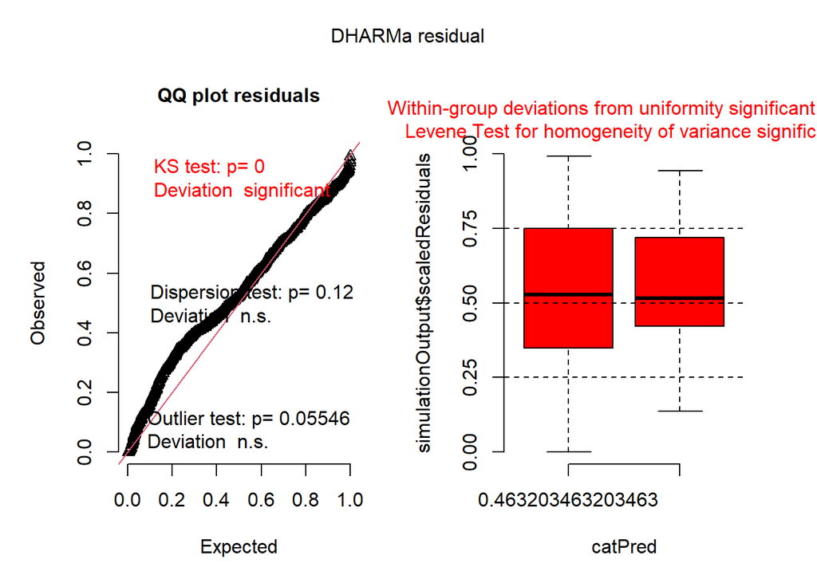

```r
res_norm <- DHARMa::simulateResiduals(fittedModel = m8)
plot(res_norm)
```

The model checks assuming Gamma distribution and log link function:

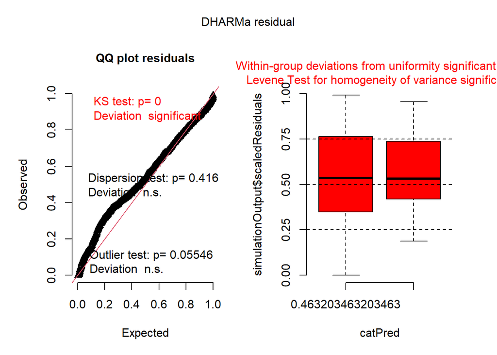

```r
res_gamma <- DHARMa::simulateResiduals(fittedModel = m9)
plot(res_gamma)
```

#### Results

Get phylogenetic signal from glmmTMB Gamma model:

```r
# get random effect component estimates on SD-scale
m9_re <- as.data.frame(confint(m9, parm="theta_"))
sigma2_s <- m9_re$Estimate[1]^2 # non-phylogenetic variance
sigma2_p <- m9_re$Estimate[2]^2 # phylogenetic variance estimate

p.signal <- sigma2_p / (sigma2_p + sigma2_s)
p.signal
```

```
[1] 0.7369
```

Get model estimated marginals means on the response scale:

```r
# Estimated marginal means on the response scale (odds)
emm_m9 <- emmeans(m9, ~ group, type = "response")
emm_m9
```

```
 group       response   SE  df asymp.LCL asymp.UCL
 Angiosperms     2.21 1.03 Inf     0.883      5.53
 Gymnosperms     4.24 1.25 Inf     2.384      7.54

Confidence level used: 0.95
Intervals are back-transformed from the log scale
```

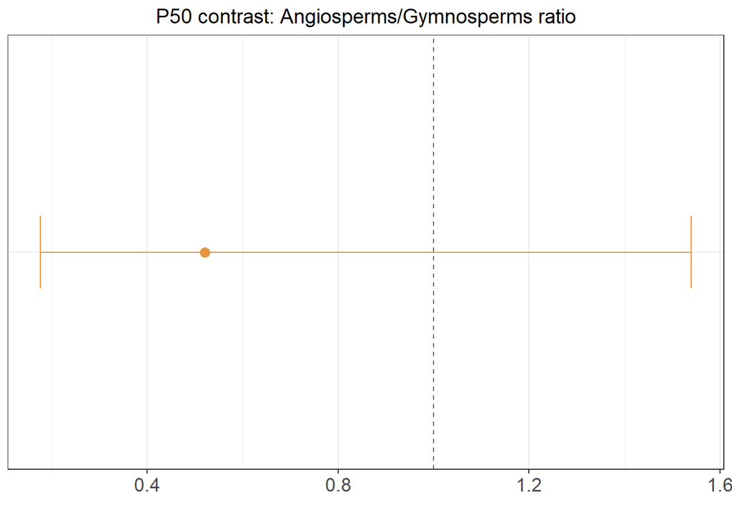

```r
# Get the contrast between the two groups
group_diff <- contrast(emm_m9, method = "pairwise", reverse=TRUE) |>
  summary(infer = TRUE, type = "response")


# Plot
p50_plot <- ggplot(group_diff, aes(y = contrast, x = ratio)) +
  geom_point(size = 3, colour = "#E49542") +
  geom_errorbar(aes(xmin = asymp.LCL, xmax = asymp.UCL),
                width = 0.2, colour = "#E49542") +
  geom_vline(xintercept = 1, linetype = "dashed", colour = "grey40") +
  labs(y = NULL, x = "",
       title = "P50 contrast: Angiosperms/Gymnosperms ratio") +
  theme_bw() +
  theme(
    legend.position = "none",
    axis.text.x = element_text(size = 13),
    axis.text.y = element_blank(),
    axis.ticks.y = element_blank(),
    plot.title = element_text(size = 14, hjust = 0.5)
  )
p50_plot
```

```r
ggsave("P50_plot.png", plot = p50_plot, width = 5, height = 3)
```

# 5 References

Barnard, J. and Rubin, D.B. (1999). Small sample degrees of freedom with multiple imputation. Biometrika, 86, 948-955.

Brooks, M. E., Kristensen, K., van Benthem, K. J., Magnusson, A., Berg, C. W., Nielsen, A., Skaug, H. J.,Machler, M., & Bolker, B. M. (2017). glmmTMB balances speed and flexibility among packages for zero-inflated generalized linear mixed modeling. R Journal, 9 (2), 378–400. https://doi.org/10.32614/RJ-2017-066

Dunn, P. O., Armenta, J. K., & Whittingham, L. A. (2015). Natural and sexual selection act on different axes of variation in avian plumage color. Science Advances, 1(2), e1400155. https://doi.org/10.1126/sciadv.1400155

Hadfield, J. D. (2024, May). MCMCglmm: MCMC Generalised Linear Mixed Models. Retrieved October 7, 2024, from https://cran.r-project.org/web/packages/MCMCglmm/index.html

Hill, G. E., & McGraw, K. J. (2006). Bird Coloration, Volume 2: Function and Evolution. Harvard University Press. https://doi.org/10.2307/j.ctv22jnr8k

Kristensen, K., & McGillycuddy, M. (2025). Covariance structures with glmmTMB. https://cran.r-project. org/web/packages/glmmTMB/vignettes/covstruct.html

McGillycuddy, M. (2023). Model-Based Assessment of Treatment Effect in Multivariate Abundance Data [Doctoral dissertation, The University of New South Wales].

Nakagawa, S., & De Villemereuil, P. (2019). A General Method for Simultaneously Accounting for Phylogenetic and Species Sampling Uncertainty via Rubin’s Rules in Comparative Analysis. Systematic Biology, 68(4), 632–641. https://doi.org/10.1093/sysbio/syy089

Rubin, D. B. (1987). Multiple Imputation for Nonresponse in Surveys (1st ed.). John Wiley & Sons, Ltd. https://doi.org/10.1002/9780470316696

Sanchez-Martinez, P., Martinez-Vilalta, J., Dexter, K. G., Segovia, R. A., & Mencuccini, M. (2020). Adaptation and coordinated evolution of plant hydraulic traits. Ecology Letters, 23 (11), 1599–1610. https://doi.org/10.1111/ele.13584

Trugman, A. T., Anderegg, L. D. L., Shaw, J. D., & Anderegg, W. R. L. (2020). Trait velocities reveal that mortality has driven widespread coordinated shifts in forest hydraulic trait composition. Proceedings of the National Academy of Sciences, 117(15), 8532–8538. https://doi.org/10.1073/pnas.1917521117

# 6 Session information

```r
library(sessioninfo)
library(details)

si <- session_info()
si$packages <- si$packages
  # |> filter(package %in% c("metafor", "ape", "clubSandwich", "Matrix", "corpcor", "dplyr", "kableExtra", "xtable", "rotl", "Hmisc", "lattice"))

details(si, summary = 'Current session info', open = FALSE)
```

**Current session info**

```r
─ Session info ───────────────────────────────────────────────────────────────
 setting  value
 version  R version 4.5.2 (2025-10-31 ucrt)
 os       Windows 11 x64 (build 26100)
 system   x86_64, mingw32
 ui       RTerm
 language (EN)
 collate  English_Australia.utf8
 ctype    English_Australia.utf8
 tz       Australia/Sydney
 date     2026-03-20
 pandoc   3.6.3 @ C:/Program Files/RStudio/resources/app/bin/quarto/bin/tools/ (via rmarkdown)
 quarto   NA @ C:\\Users\\z5394590\\AppData\\Local\\Programs\\Quarto\\bin\\quarto.exe

─ Packages ───────────────────────────────────────────────────────────────────
 ! package           * version    date (UTC) lib source
   abind               1.4-8      2024-09-12 [1] CRAN (R 4.5.2)
   ape               * 5.8-1      2024-12-16 [1] CRAN (R 4.5.2)
   backports           1.5.0      2024-05-23 [1] CRAN (R 4.5.2)
   bayesplot           1.15.0     2025-12-12 [1] CRAN (R 4.5.2)
   bayestestR        * 0.17.0     2025-08-29 [1] CRAN (R 4.5.2)
   bit                 4.6.0      2025-03-06 [1] CRAN (R 4.5.2)
   bit64               4.6.0-1    2025-01-16 [1] CRAN (R 4.5.2)
   boot                1.3-32     2025-08-29 [2] CRAN (R 4.5.2)
   bridgesampling      1.2-1      2025-11-19 [1] CRAN (R 4.5.2)
   brms              * 2.23.0     2025-09-09 [1] CRAN (R 4.5.2)
   Brobdingnag         1.2-9      2022-10-19 [1] CRAN (R 4.5.2)
   broom               1.0.12     2026-01-27 [1] CRAN (R 4.5.2)
   broom.mixed       * 0.2.9.6    2024-10-15 [1] CRAN (R 4.5.2)
   cachem              1.1.0      2024-05-16 [1] CRAN (R 4.5.2)
   cellranger          1.1.0      2016-07-27 [1] CRAN (R 4.5.2)
   checkmate           2.3.3      2025-08-18 [1] CRAN (R 4.5.2)
   class               7.3-23     2025-01-01 [2] CRAN (R 4.5.2)
   classInt            0.4-11     2025-01-08 [1] CRAN (R 4.5.2)
   cli                 3.6.5      2025-04-23 [1] CRAN (R 4.5.2)
   clipr               0.8.0      2022-02-22 [1] CRAN (R 4.5.2)
   cluster             2.1.8.1    2025-03-12 [2] CRAN (R 4.5.2)
   clusterGeneration   1.3.8      2023-08-16 [1] CRAN (R 4.5.2)
   coda              * 0.19-4.1   2024-01-31 [1] CRAN (R 4.5.2)
   codetools           0.2-20     2024-03-31 [2] CRAN (R 4.5.2)
   combinat            0.0-8      2012-10-29 [1] CRAN (R 4.5.2)
   corpcor             1.6.10     2021-09-16 [1] CRAN (R 4.5.2)
   crayon              1.5.3      2024-06-20 [1] CRAN (R 4.5.2)
   cubature            2.1.4-1    2025-11-22 [1] CRAN (R 4.5.2)
   curl                7.0.0      2025-08-19 [1] CRAN (R 4.5.2)
   data.table        * 1.18.0     2025-12-24 [1] CRAN (R 4.5.2)
   DBI                 1.3.0      2026-02-25 [1] CRAN (R 4.5.2)
   DEoptim             2.2-8      2022-11-11 [1] CRAN (R 4.5.2)
   desc                1.4.3      2023-12-10 [1] CRAN (R 4.5.2)
   deSolve             1.40       2023-11-27 [1] CRAN (R 4.5.2)
   details           * 0.4.0      2025-02-09 [1] CRAN (R 4.5.2)
   devtools          * 2.4.6      2025-10-03 [1] CRAN (R 4.5.2)
   DHARMa            * 0.4.7      2024-10-18 [1] CRAN (R 4.5.2)
   digest              0.6.39     2025-11-19 [1] CRAN (R 4.5.2)
   distributional      0.5.0      2024-09-17 [1] CRAN (R 4.5.2)
   doParallel          1.0.17     2022-02-07 [1] CRAN (R 4.5.2)
   dplyr             * 1.2.0      2026-02-03 [1] CRAN (R 4.5.2)
   e1071               1.7-17     2025-12-18 [1] CRAN (R 4.5.2)
   ellipsis            0.3.2      2021-04-29 [1] CRAN (R 4.5.2)
   emmeans           * 2.0.2      2026-03-05 [1] CRAN (R 4.5.2)
   estimability        1.5.1      2024-05-12 [1] CRAN (R 4.5.2)
   evaluate            1.0.5      2025-08-27 [1] CRAN (R 4.5.2)
   expm                1.0-0      2024-08-19 [1] CRAN (R 4.5.2)
   farver              2.1.2      2024-05-13 [1] CRAN (R 4.5.2)
   fastmap             1.2.0      2024-05-15 [1] CRAN (R 4.5.2)
   fastmatch           1.1-6      2024-12-23 [1] CRAN (R 4.5.2)
   fmesher             0.6.1      2025-12-12 [1] CRAN (R 4.5.2)
   forcats           * 1.0.1      2025-09-25 [1] CRAN (R 4.5.2)
   foreach             1.5.2      2022-02-02 [1] CRAN (R 4.5.2)
   fs                  1.6.6      2025-04-12 [1] CRAN (R 4.5.2)
   furrr               0.3.1      2022-08-15 [1] CRAN (R 4.5.2)
   future              1.68.0     2025-11-17 [1] CRAN (R 4.5.2)
   future.apply        1.20.1     2025-12-09 [1] CRAN (R 4.5.2)
   gap                 1.6        2024-08-27 [1] CRAN (R 4.5.2)
   gap.datasets        0.0.6      2023-08-25 [1] CRAN (R 4.5.2)
   geiger            * 2.0.11     2023-04-03 [1] CRAN (R 4.5.2)
   generics            0.1.4      2025-05-09 [1] CRAN (R 4.5.2)
   geometry            0.5.2      2025-02-08 [1] CRAN (R 4.5.2)
   ggplot2           * 4.0.2      2026-02-03 [1] CRAN (R 4.5.2)
   glmmTMB           * 1.1.14     2026-01-15 [1] CRAN (R 4.5.2)
   glmnet              4.1-10     2025-07-17 [1] CRAN (R 4.5.2)
   globals             0.18.0     2025-05-08 [1] CRAN (R 4.5.2)
   glue                1.8.0      2024-09-30 [1] CRAN (R 4.5.2)
   gridExtra           2.3        2017-09-09 [1] CRAN (R 4.5.2)
   gtable              0.3.6      2024-10-25 [1] CRAN (R 4.5.2)
   here              * 1.0.2      2025-09-15 [1] CRAN (R 4.5.2)
   hms                 1.1.4      2025-10-17 [1] CRAN (R 4.5.2)
   htmltools           0.5.9      2025-12-04 [1] CRAN (R 4.5.2)
   htmlwidgets         1.6.4      2023-12-06 [1] CRAN (R 4.5.2)
   httr                1.4.8      2026-02-13 [1] CRAN (R 4.5.2)
   igraph              2.2.1      2025-10-27 [1] CRAN (R 4.5.2)
   INLA              * 25.10.19   2025-10-19 [1] local
   inline              0.3.21     2025-01-09 [1] CRAN (R 4.5.2)
   insight             1.4.6      2026-02-04 [1] CRAN (R 4.5.2)
   iterators           1.0.14     2022-02-05 [1] CRAN (R 4.5.2)
   jomo                2.7-6      2023-04-15 [1] CRAN (R 4.5.2)
   jsonlite            2.0.0      2025-03-27 [1] CRAN (R 4.5.2)
   KernSmooth          2.23-26    2025-01-01 [2] CRAN (R 4.5.2)
   knitr             * 1.51       2025-12-20 [1] CRAN (R 4.5.2)
   labeling            0.4.3      2023-08-29 [1] CRAN (R 4.5.2)
   lattice             0.22-7     2025-04-02 [2] CRAN (R 4.5.2)
   lifecycle           1.0.5      2026-01-08 [1] CRAN (R 4.5.2)
   lightr              1.9.0      2025-07-21 [1] CRAN (R 4.5.2)
   listenv             0.10.0     2025-11-02 [1] CRAN (R 4.5.2)
   lme4                1.1-38     2025-12-02 [1] CRAN (R 4.5.2)
   loo                 2.9.0      2025-12-23 [1] CRAN (R 4.5.2)
   lubridate         * 1.9.4      2024-12-08 [1] CRAN (R 4.5.2)
   magic               1.6-1      2022-11-16 [1] CRAN (R 4.5.2)
   magick              2.9.0      2025-09-08 [1] CRAN (R 4.5.2)
   magrittr            2.0.4      2025-09-12 [1] CRAN (R 4.5.2)
   maps              * 3.4.3      2025-05-26 [1] CRAN (R 4.5.2)
   MASS              * 7.3-65     2025-02-28 [2] CRAN (R 4.5.2)
   Matrix            * 1.7-4      2025-08-28 [1] CRAN (R 4.5.2)
   matrixStats         1.5.0      2025-01-07 [1] CRAN (R 4.5.2)
   MCMCglmm          * 2.36       2024-05-06 [1] CRAN (R 4.5.2)
   memoise             2.0.1      2021-11-26 [1] CRAN (R 4.5.2)
   mgcv                1.9-4      2025-11-07 [1] CRAN (R 4.5.2)
   mice              * 3.19.0     2025-12-10 [1] CRAN (R 4.5.2)
   minqa               1.2.8      2024-08-17 [1] CRAN (R 4.5.2)
   misc3d              0.9-1      2021-10-07 [1] CRAN (R 4.5.2)
   mitml             * 0.4-5      2023-03-08 [1] CRAN (R 4.5.2)
   mnormt              2.1.1      2022-09-26 [1] CRAN (R 4.5.2)
   multcomp            1.4-29     2025-10-20 [1] CRAN (R 4.5.2)
   mvtnorm             1.3-3      2025-01-10 [1] CRAN (R 4.5.2)
   nlme                3.1-168    2025-03-31 [2] CRAN (R 4.5.2)
   nloptr              2.2.1      2025-03-17 [1] CRAN (R 4.5.2)
   nnet                7.3-20     2025-01-01 [2] CRAN (R 4.5.2)
   numDeriv            2016.8-1.1 2019-06-06 [1] CRAN (R 4.5.2)
   optimParallel       1.0-2      2021-02-11 [1] CRAN (R 4.5.2)
   otel                0.2.0      2025-08-29 [1] CRAN (R 4.5.2)
   pacman              0.5.1      2019-03-11 [1] CRAN (R 4.5.2)
   pan                 1.9        2023-08-21 [1] CRAN (R 4.5.2)
   parallelly          1.46.0     2025-12-12 [1] CRAN (R 4.5.2)
   pavo              * 2.9.0      2023-09-24 [1] CRAN (R 4.5.2)
   performance       * 0.15.3     2025-12-01 [1] CRAN (R 4.5.2)
   phangorn            2.12.1     2024-09-17 [1] CRAN (R 4.5.2)
   phyr              * 1.1.3      2025-11-11 [1] CRAN (R 4.5.2)
   phytools          * 2.5-2      2025-09-19 [1] CRAN (R 4.5.2)
   pillar              1.11.1     2025-09-17 [1] CRAN (R 4.5.2)
   pkgbuild            1.4.8      2025-05-26 [1] CRAN (R 4.5.2)
   pkgconfig           2.0.3      2019-09-22 [1] CRAN (R 4.5.2)
   pkgload             1.4.1      2025-09-23 [1] CRAN (R 4.5.2)
   plot3D              1.4.2      2025-07-25 [1] CRAN (R 4.5.2)
   plyr                1.8.9      2023-10-02 [1] CRAN (R 4.5.2)
   png                 0.1-8      2022-11-29 [1] CRAN (R 4.5.2)
   posterior           1.6.1      2025-02-27 [1] CRAN (R 4.5.2)
   progressr           0.18.0     2025-11-06 [1] CRAN (R 4.5.2)
   proxy               0.4-29     2025-12-29 [1] CRAN (R 4.5.2)
   purrr             * 1.2.1      2026-01-09 [1] CRAN (R 4.5.2)
   quadprog            1.5-8      2019-11-20 [1] CRAN (R 4.5.2)
   QuickJSR            1.8.1      2025-09-20 [1] CRAN (R 4.5.2)
   R6                  2.6.1      2025-02-15 [1] CRAN (R 4.5.2)
   ragg                1.5.1      2026-03-06 [1] CRAN (R 4.5.2)
   rbenchmark        * 1.0.0      2012-08-30 [1] CRAN (R 4.5.2)
   rbibutils           2.4.1      2026-01-21 [1] CRAN (R 4.5.2)
   RColorBrewer        1.1-3      2022-04-03 [1] CRAN (R 4.5.2)
   Rcpp              * 1.1.1      2026-01-10 [1] CRAN (R 4.5.2)
 D RcppParallel        5.1.11-1   2025-08-27 [1] CRAN (R 4.5.2)
   Rdpack              2.6.6      2026-02-08 [1] CRAN (R 4.5.2)
   readr             * 2.2.0      2026-02-19 [1] CRAN (R 4.5.2)
   readxl            * 1.4.5      2025-03-07 [1] CRAN (R 4.5.2)
   reformulas          0.4.4      2026-02-02 [1] CRAN (R 4.5.2)
   remotes             2.5.0      2024-03-17 [1] CRAN (R 4.5.2)
   reshape2            1.4.5      2025-11-12 [1] CRAN (R 4.5.2)
   rlang               1.1.7      2026-01-09 [1] CRAN (R 4.5.2)
   rmarkdown         * 2.30       2025-09-28 [1] CRAN (R 4.5.2)
   rpart               4.1.24     2025-01-07 [2] CRAN (R 4.5.2)
   rprojroot           2.1.1      2025-08-26 [1] CRAN (R 4.5.2)
   rstan               2.32.7     2025-03-10 [1] CRAN (R 4.5.2)
   rstantools          2.6.0      2026-01-10 [1] CRAN (R 4.5.2)
   rstudioapi          0.18.0     2026-01-16 [1] CRAN (R 4.5.2)
   S7                  0.2.1      2025-11-14 [1] CRAN (R 4.5.2)
   sandwich            3.1-1      2024-09-15 [1] CRAN (R 4.5.2)
   scales              1.4.0      2025-04-24 [1] CRAN (R 4.5.2)
   scatterplot3d       0.3-44     2023-05-05 [1] CRAN (R 4.5.2)
   sessioninfo       * 1.2.3      2025-02-05 [1] CRAN (R 4.5.2)
   sf                  1.0-23     2025-11-28 [1] CRAN (R 4.5.2)
   shape               1.4.6.1    2024-02-23 [1] CRAN (R 4.5.2)
   splitstackshape   * 1.4.8      2019-04-21 [1] CRAN (R 4.5.2)
   StanHeaders         2.32.10    2024-07-15 [1] CRAN (R 4.5.2)
   stringi             1.8.7      2025-03-27 [1] CRAN (R 4.5.2)
   stringr           * 1.6.0      2025-11-04 [1] CRAN (R 4.5.2)
   subplex             1.9        2024-07-05 [1] CRAN (R 4.5.2)
   survival            3.8-3      2024-12-17 [2] CRAN (R 4.5.2)
   systemfonts         1.3.1      2025-10-01 [1] CRAN (R 4.5.2)
   tensorA             0.36.2.1   2023-12-13 [1] CRAN (R 4.5.2)
   textshaping         1.0.4      2025-10-10 [1] CRAN (R 4.5.2)
   TH.data             1.1-5      2025-11-17 [1] CRAN (R 4.5.2)
   tibble            * 3.3.1      2026-01-11 [1] CRAN (R 4.5.2)
   tidyr             * 1.3.2      2025-12-19 [1] CRAN (R 4.5.2)
   tidyselect          1.2.1      2024-03-11 [1] CRAN (R 4.5.2)
   tidyverse         * 2.0.0      2023-02-22 [1] CRAN (R 4.5.2)
   timechange          0.3.0      2024-01-18 [1] CRAN (R 4.5.2)
   TMB                 1.9.19     2025-12-15 [1] CRAN (R 4.5.2)
```

```r
   tzdb                0.5.0      2025-03-15 [1] CRAN (R 4.5.2)
   units               1.0-0      2025-10-09 [1] CRAN (R 4.5.2)
   usethis           * 3.2.1      2025-09-06 [1] CRAN (R 4.5.2)
   utf8                1.2.6      2025-06-08 [1] CRAN (R 4.5.2)
   V8                  8.0.1      2025-10-10 [1] CRAN (R 4.5.2)
   vctrs               0.7.1      2026-01-23 [1] CRAN (R 4.5.2)
   vroom             * 1.7.0      2026-01-27 [1] CRAN (R 4.5.2)
   withr               3.0.2      2024-10-28 [1] CRAN (R 4.5.2)
   xfun                0.55       2025-12-16 [1] CRAN (R 4.5.2)
   xml2                1.5.1      2025-12-01 [1] CRAN (R 4.5.2)
   xtable              1.8-4      2019-04-21 [1] CRAN (R 4.5.2)
   yaml                2.3.12     2025-12-10 [1] CRAN (R 4.5.2)
   zoo                 1.8-15     2025-12-15 [1] CRAN (R 4.5.2)

 [1] C:/Users/z5394590/AppData/Local/R/win-library/4.5
 [2] C:/Program Files/R/R-4.5.2/library

 * ── Packages attached to the search path.
 D ── DLL MD5 mismatch, broken installation.

──────────────────────────────────────────────────────────────────────────────
```

> **Note**

Bird icon created by [Smashicons - Flaticon](https://www.flaticon.com/free-icons/bird)